# The Ascetic Programmer

## 1.5 Verbosity and Bloatware

While this book’s main focus so far has been on concise or frugal software, and its verbose and bloated counterpart has been mentioned only as a point of comparison, this is a section devoted to the latter. Just as the bad guys are often more entertaining in fiction, “verboseware” and bloatware have inspired some juicy stories.

They also have some surprising supporters. Concise software has a bad reputation that goes back to the same Dijkstra that we quoted (see section Sec. 1.1) warning about the threat represented by large programs [39]:

> […] a specific phenomenon occurs that even has a well-established name: it is called “the one-liners”. […] one programmer places a one-line program on the desk of another and […] adds the question “Can you code this in less symbols?” — as if this were of any conceptual relevance!

It is somewhat puzzling that he would not consider for a moment that there may be some relation between reducing 10 LOCs to 1 and reducing 1 million to 100,000, even if different techniques apply at different scales. However, as we have seen in Sec. 1.2.4, his answer was to produce better-structured code, not less of it.

He isn’t the only instance of a Turing awardee defending verbosity in his Turing lecture. Recalling what he considered a youthful mistake, Hoare said [204]:

> [For the successor to ALGOL60] my suggestion was to […] relax the ALGOL60 rule of compulsory declaration of variable names […] It was pointed out that the redundancy of ALGOL60 was the best protection against programming and coding errors […] The story of the Mariner space rocket to Venus, lost because of the lack of compulsory declarations in FORTRAN, wasn’t to be published until later.

Hoare seems to embrace the widespread belief that a missed hyphen in Mariner I’s control program caused its premature loss. An inquiry later established that the error was equally minute but in its specification, not in the program itself [237]. Nonetheless, the false belief stuck, as good stories have a way of doing. He continues:

> I was eventually persuaded of the need to design programming notations so as to maximize the number of errors which cannot be made, or if made, can be reliably detected at compile time. Perhaps this would make the text of programs longer. Never mind! Wouldn’t you be delighted if your Fairy Godmother offered to wave her wand over your program to remove all its errors and only made the condition that you should write out and key in your whole program three times!

Unfortunately, variable declarations, let alone retyping entire programs, are a primitive way to spell-check variables. I haven’t seen any evidence that languages with this characteristic have a lower bug density, but there is plenty of evidence that they have more lines. Modern IDEs will catch misspelled and uninitialized variables, and the declarative information is “vital” because some compilers use it to allocate the correct amount of memory.

The warnings about the pitfalls of large programs have been around for a long time. The Unix Philosophy, as summarized by open source advocate Eric Raymond, includes this rule about large programs [238]:

> Rule of Parsimony: Write a big program only when it is clear by demonstration that nothing else will do.

That doesn’t ensure that modern versions of Unix don’t violate this principle. For instance, Systemd, a Linux program, is “an init system used to bootstrap user space and manage user processes,” which “also provides replacements for various daemons and utilities, including device management, login management, network connection management, and event logging” [239]. It exceeds 1.3 MLOCs and controversially centralizes several responsibilities previously dealt with by separate, smaller programs. Several notable Linux developers have criticized it, but major Linux distributions install it by default [240].

This trend is by no means limited to the Unix world, albeit in strident contrast with its original philosophy in its case. It affects the software industry as a whole, despite its negative consequences [12]. We have seen in Sec. 1.1 that the size of a program predicts, to some degree, the number of errors to be found in it and the probability of its failure as an engineering project. Yet, there are further ramifications, such as security-related ones.

For instance, consider signing onto web sites using your Facebook credentials (a feature known as single sign-on). The problem isn’t just creating a single point of failure for all of your authentication needs; it is trusting the security of Facebook authentication in the first place. Jason Polakis, an assistant professor of computer science at the University of Illinois at Chicago and an expert on single sign-on, puts it as follows [241]:

> The codebase of these services is massive. You have different teams working on different components, and they can interplay in different ways, and you can have a crazy hack that no one expects.

He could have mentioned Facebook’s “move fast and break things” motto, which doesn’t bode well for security, or other reputation-busting activities that made the news. Instead, he focused on the enormous attack surface represented by its sprawling code base, a problem shared with all the other tech behemoths. Polakis was being interviewed on the occasion of a security breach at the social network, affecting 50 million users.

A similar, code-size-based explanation was proposed by Zulfikar Ramzan, CTO at a cloud security startup, for a well-publicized bug known as *Heartbleed* [242]:

> […] when I looked at the flaw myself I said, “Obviously, this is a pretty simple error.” This comes down to the issue that there’s so much code out there right now, and there’s so much code people are writing. There was a particular protocol called Heartbeat that did not get as much scrutiny.

To be precise, Heartbeat is an extension of TSL and DTSL, two protocols underlying secure communication on the web [243]. We can imagine a world without this feature but also free of the criminal activity enabled by its implementation errors. Indeed, before a patch became available, a recommended workaround was to turn it off. Whoever decided to add it and whoever, most likely inadvertently, introduced this bug will not foot the bill for said activity.

A company that may regret writing so much code is Boeing. It is building Starliner, a space capsule for crewed missions. After a bug was identified and corrected in its control software while in orbit, Boeing decided to review the whole code base for the project, as several additional bugs pointed to a development process failure. Unfortunately for them, there were already a million LOCs to review [244]. It would seem wise to check a company’s development process before reaching the one MLOC mark, let alone having a spaceship in orbit, but that didn’t happen in this instance. I can’t help but imagine a million LOCs written at the speed that some ascribe to this kind of project, namely, one LOC per programmer per day (see Sec. 1.2.1).

Talking about space exploration, I run into this code comment, part of the container[^97] management software Kubernetes [245]:

> PLEASE DO NOT ATTEMPT TO SIMPLIFY THIS CODE. KEEP THE SPACE SHUTTLE FLYING. This controller is intentionally written in a very verbose style.

The comments further dictate that that program section can only be added to because it is written in this style. Reportedly, it is used at NASA in some contexts to prevent bugs from occurring. Its rationale is that if the code lists all possible conditions in a cascade of ifs, then no condition will be unaccounted for, even if some branches do nothing. However, I don’t know if this approach is widely adopted at NASA or if there is any evidence it contributes to program correctness.

Can large code bases be responsible for crimes, or at least provide a mitigating circumstance for the people accused of those crimes? Eddie Tipton, the confessed mastermind of the largest lottery fraud in US history, apparently tried to suggest this idea. Speaking in court about the system running the lottery, he said [246]:

> [The lottery code] just kept growing and growing, […] It became spaghetti codes [sic], unfortunately.

The jury wasn’t moved and sentenced him to 10 years, eventually adding up to 25 in combination with other sentences. Rigging spaghetti code, albeit unpleasant, is still rigging.

Website operators and developers should be particularly sensitive to the size issue because web pages, with their associated media and code, have to travel over the wire to impatient users, who may move on rather than wait. Unfortunately, nothing is furthest from the truth. While many techniques have been adopted to accelerate page load, restraint in designing pages isn’t one of those. In an entertaining presentation, Maciej Cegłowski, a web entrepreneur and activist, details what he calls “the website obesity crisis” [247]. He compares the size of pages of popular websites to that of major works of literature. His prescription is drastic:

> I want to share with you my simple two-step secret to improving the performance of any website.  
> Make sure that the most important elements of the page download and render first.  
> Stop there.  
> You don’t need all that other crap. Have courage in your minimalism.

He calls for less of everything other than human-readable text: fewer images and videos, less Javascript and tracking tags. His blog’s home page is over 56% text; by comparison, the corresponding figure for cnn.com is 0.21% [248].

Typically, more planning and thinking go into designing a language than a website. Language designers should know that keeping their creations small makes them more accessible. On the other hand, faced with a long list of requirements, they may try to meet them at the cost of more complexity. That might be what happened to the ADA language, designed in response to a call for proposals by the Department of Defense. None of the existing languages had been found to meet the complex requirements for a general-purpose programming language for defense-related projects. The result wasn’t encouraging [249]:

> [The developers of] early Ada [sic] compilers struggled to implement the large, complex language, and both compile-time and run-time performance tended to be slow and tools primitive.

Hoare took time during his Turing Award Lecture to criticize ADA, as well as PL/1 and Algol 68, as too complex and therefore unreliable (apparently, being the awardee didn’t put him in a charitable mood) [204]. His experience with complex languages goes back to his work on designing a successor for Algol 60, during which he had to watch in disbelief as a simple, incremental proposal was sidelined in favor of a much more elaborate and, in his opinion, unfeasible design. Of this, he wrote:

> […] there are two ways of constructing a software design: One way is to make it so simple that there are obviously no deficiencies and the other way is to make it so complicated that there are no obvious deficiencies. The first method is far more difficult.

It became, after many delays, the quickly abandoned Algol 68.

About ADA, which was designed to become the standard programming language for the Department of Defense, he warned:

> Do not allow this language in its present state to be used in applications where reliability is critical, i.e., nuclear power stations, cruise missiles, early warning systems, anti-ballistic missile defense systems. The next rocket to go astray as a result of a programming language error may not be an exploratory space rocket on a harmless trip to Venus [see Mariner I above]: It may be a nuclear warhead exploding over one of our own cities. An unreliable programming language generating unreliable programs constitutes a far greater risk to our environment and to our society than unsafe cars, toxic pesticides, or accidents at nuclear power stations.

It is at least debatable whether this prediction has proven accurate. I can’t think of a software error that caused devastation even remotely comparable to that of the Chernobyl or Fukushima disasters, even if the MCAS-related accidents (see Sec. 1.6), for instance, resulted in more short-term casualties. However, by most accounts, they were not due to the programming language used.

ADA continues to be used in defense and other security-sensitive applications, like flight control for aviation and space. Yet, its adoption rate pales compared to another problematic language, SQL, which is “by far the most used database language” [250]. The same reference contains a well-reasoned criticism of SQL but, for our goals, the following paragraph stands out:

> SQL is not a small language. At the time of writing the PostgreSQL implementation contains 469 keywords. Just part 2 (out of 14) of the SQL:2016 standard has 1732 pages.

By comparison, JavaScript has 64 reserved words in its ECMAScript 5/6 standard [251]. Other issues with SQL make queries long and hard to read and inhibit query reuse (see Sec. 1.2.9.9 and Sec. 1.2.10.1). The inventor of the relational model, Edgar F. Codd, devotes a whole chapter in one of his books to SQL’s “serious flaws” [252].

If the DRY principle (see Sec. 1.2.3) guides Python and Ruby programmers, Java should be considered a WET language — for Write Explicitly Tenfold. We have already encountered its proverbial verbosity in comparisons to Clojure (see Sec. 1.2.9.1) and Scala (see Sec. 1.2.10.1). However, the most extreme example of irreducible verbosity must be the one in `java.util.Arrays`, a module of the Java standard library. One of its authors is the same Joshua Bloch who preaches the gospel of minimalistic APIs (see Sec. 1.2.8). In an older version, we could find the following fatalist comment [253]:

> The code for each of the seven primitive types is largely identical. C’est la vie.[^98]

Let us consider that this is as idiomatic Java as it gets, co-authored by three principal contributors to the development of the language. Apparently, Java has no abstraction mechanism to avoid this 7-fold duplication without a performance penalty, which isn’t acceptable in a foundational array library. More recently, the comment disappeared, but the repetitive code remains.

Verbosity isn’t just an inconvenience or a maintenance burden: it can kill complete subfields of computing. At least, this is what Jonathan Dursi puts forward in his post: “HPC is dying, and MPI is killing it” [254]. He accuses MPI, a dominant library for High-Performance Computing, of forcing practitioners to a lower level of abstraction than most need. Moreover, compared to modern alternatives like Spark and Chapel, he shows that MPI takes over twice as much code while leaving fault tolerance to the developer.

Anecdotally, most engineers have had to deal with awful code in their careers, particularly of the verbose variety. Hacker News user conceptjunkie comes to a sobering conclusion [255]:

> I don’t know about you, but I’ve rarely worked on a codebase that *wasn’t* awful in some way, and I am definitely not early in my career. I’ve come to the conclusion that most programmers are simply awful at their jobs, and the developers that can write clear, concise code are a small minority. I’ve known a few, but not many.

I hold a slightly less pessimistic view. It may be that too many people have rapidly entered this field for most of them to have a talent for or a deep interest in computing. However, terrible developers don’t need to be a majority to produce a much larger number of LOCs than their concise peers. Good, concise code is hidden among the KLOCs and MLOCs of verbose horrors.

Moreover, bad code begets bad code. For example, I once needed a particular time-related function, and I thought someone at a client of mine had likely written it before. I found related functions everywhere, from database-related modules to the UI. The search had taken me already longer than writing my own implementation. Should I have started a refactor to bring all these functions into one module while eliminating duplications, or just followed the most direct route to meet my deadline? In most companies, an engineer is not free to make such a decision. You can’t go to a team meeting and say that you won’t meet a deadline because you started a refactor of your own accord. You would be asked immediately: is this refactor a *blocker*? That is, is its completion a necessary condition to perform the original task? Of course it isn’t, because you can pile up a bit more *technical debt*,[^99] let the rot spread a little and meet your deadline. Indeed, you are required to.

This experience brings up a final point: the dominant incentive structure isn’t aligned with quality. Development these days is fragmented into long series of self-inflicted emergencies, whereby invented deadlines and the language used by management are meant to create pressure. It is like trying to win a marathon, going as fast as possible for the first 100 yards, then again and again. It is a technical debt factory. We know the aphorism: “quality, time or resources, pick two.” Since individual contributors don’t have access to additional engineering resources, and time is set by management or the fastest, least scrupulous coworker, quality has to yield. It becomes a race to the bottom, doing the least for a new feature to pass equally rushed tests, product, and code reviews. Week after week, a developer will be called to work on someone else’s awful code and someone else will mess up whatever good there in this developer’s. It is irrational to expect good work to be performed in this environment. It is inevitable that conciseness, which is seldom even recognized as a quality factor, is one of the victims.

## 1.6 Code Considered Harmful

Some engineers react to the realities of horrible code by trying to write good code, including eliminating verbosity. Others take a more pessimistic position, denying the possibility of writing concise code or using features appropriately. Their approach is more radical: elimination.

Developers likely recognized, in this section’s title, a play on “Go To Statement Considered Harmful,” an essay in which Dijkstra criticized the `goto` statement, which causes a program to continue at a line identified by a number or a label [256]. Dijkstra endeavored to rewrite programs without the `goto` and reported that “In all cases tried […] the program without goto statements turned out to be shorter and more lucid” [257]. It is the prototype of all attacks on language features and the only one to succeed to a great extent. Indeed, many modern languages don’t support this construct. This omission can be worked around at the cost of a modest increase in code length or by using alternative instructions such as `break` or `return`. That `goto` isn’t needed is also supported by the Böhm-Jacopini theorem, which shows that any program can be rewritten without `goto` ([258]; see also [259]). More than the statement itself, it is noteworthy that its proof builds a `goto`-free version of a program via incremental modifications, rather than just claiming Turing equivalence.[^100] In other words, ridding programs of `goto`s doesn’t require rewriting them from the ground up. The main argument against the `goto` is that it made programs hard to understand by allowing a combinatorial explosion of the possible execution paths through the code. Well-known voices expressing qualified support for the `goto` are those of Donald Knuth [260], author of *The Art of Computer Programming*, and Torvalds [261]. Both find that it has applications where it seems the most appropriate construct. I have seen excellent programs written with `goto` as the only available control statement and terrible ones written without a single `goto`. Indeed, it is a feature prone to abuse, but many others dangerous features are defended based on their power and under the optimistic assumption that only competent people will use them. I don’t miss the `goto`, but I feel like a double standard was applied to it.

On the evidence that suppressing the `goto` didn’t solve the ills of software development — but it may have mitigated them — the scapegoating of language features could have fallen out of favor, but it hasn’t. There is a budding effort to discourage the use of the `if` statement. Francesco Cirillo, the consultant who invented the Pomodoro Technique, has penned an “Anti-If Manifesto” [262]:

> Have you ever wondered how IFs impact on [sic] your code? Avoid dangerous IFs and use Objects to build a code that is flexible, changeable and easily testable, and will help avoid a lot of headaches and weekends spent debugging!

I understand this is an effort to replace `if`s with method dispatch,[^101] substituting the implicit checking of types for the explicit checking of conditions. Equivalently, it moves the responsibility for type checking from the caller to the callee, an instance of what Bloch recommends for APIs (don’t let the user do what the API can take care of, see Sec. 1.2.8). I am less clear why this is framed as an attack on the `if` statement rather than a pitch for object-oriented programming and, specifically, polymorphism[^102] or whether Cirillo writes or foresees programs free of `if`s.

While `if` fights for its life, the detractors of class inheritance,[^103] which is closely related to polymorphism, are building up their ranks [263]. As language evolution continues to be based on a popularity contest, as opposed to hard evidence, we miss opportunities to make actual progress.

If sending individual features into oblivion isn’t enough, why not reduce code to fragments? This is more or less what Robert C. Martin proposes in his best-seller *Clean Code* [264]:

> The first rule of functions is that they should be small. The second rule of functions is that they should be smaller than that.

There is only one way to fulfill this requirement: limiting every function to one line — I considered the zero lines solution but ran into mathematical difficulties. It likely isn’t meant to be taken too literally because, elsewhere in the book, the ideal function length is set at two to four lines. This precept is absolute and independent of other considerations, including:

- whether these functions will be called more than once;
- whether four lines accomplish anything that can be described or tested;
- whether high-quality libraries follow this guideline;
- conciseness or time limits, as function definitions take their own space and effort.

You may be writing this madness off as a necessary hyperbole to make a book sell, but that would be premature. I once reviewed a 60-KLOC code base that approached this ideal closely. Function names were summaries of their own minuscule bodies, and formal and actual parameters had the same names. I expect this to be hard to imagine even for battle-hardened programmers, so let me clarify with an example (not from the actual code). A statement like `table2 = join("table0", "table1")` would be transformed into:

```python
def join_table0_table1(table0, table1):
  return join(table0, table1)

table0 = "table0"
table1 = "table1"
table2 = join_table0_table1(table0, table1)
```

Some put the blame for code verbosity squarely on developers. For example, Tyler Treat, a developer himself by training, writes [265]:

> […] you are not paid to write code. You have never been paid to write code. Indeed, code is a nasty byproduct of being a software engineer.

These statements must sound outlandish to whoever makes a living writing code and are possibly explained by Treat having reached the level of “managing partner,” several levels above the coding trenches. The decisions about whether to write code or not aren’t made by developers in most contexts. A developer not producing code is considered an idle one. For instance, news outlets reported that Twitter engineers, facing a review in preparation for massive layoffs, had to provide management with 50 pages of code produced during the last 30 days, or roughly 90 LOCs per day — a “nasty byproduct” of trying to keep their jobs (and 18 times faster than Kamp wrote Varnish, see Sec. 1.2.1)[266].

A piece of code that turned out to be harmful, even deadly, was the infamous M. C. A. S., a patch in the control software of the new Boeing 737 Max necessitated by changes in engine size and position [267]:

> After weighing many possibilities […] Boeing decided to add a new program — what engineers described as essentially some lines of code — to the aircraft’s existing flight control system to counter the destabilizing pitching forces from the new engines.  
> That program was M. C. A. S.

The new code, together with hardware flaws, resulted in the total loss of two airplanes, with all 346 passengers and crew. It may look like a concise addition to the existing control software — just a few LOCs. However, an ill-advised addition it was: a plane initially designed with intrinsic stability and ultimate pilot control over any electronic aid was modified into one with a computer override in a crucially unstable condition ([268], [269]). As an additional risk factor, the changes had to be downplayed to convince clients and regulatory authorities that the new airplane was essentially the same as the previous 737, sidestepping expensive retraining and certification requirements. Aircrafts developed more recently, both by Boeing and its main competitor, Airbus, are designed for computer control. As a result, they didn’t incur any of the software problems of the 737 MAX.

Going back to Brooks and the early days of computing, he discusses the delicate balance between adding features and adding complexity, both for the user and the developer. A system that he is particularly fond of is the IBM 650 ([5]; see Fig. 1):

> I am haunted by the memory of the ease of use of the IBM 650, even without an assembler or any other software at all.

You got it right: his favorite system was software-less, bare hardware. Later, it received an assembly language and other software, possibly spoiling the user experience.

Knuth got his computing career started working on the same model. He, too, has fond memories of it [270]:

> […] There was something special about the IBM 650, something that has provided much of the inspiration for my life’s work. Somehow this machine was powerful in spite of its severe limitations. Somehow it was friendly in spite of its primitive man-machine interface. […] The 650 had only 44 operation codes, while the 709 had more than 200 [see Sec. 1.4]; yet I never enjoyed coding for the 709, because I never seemed to be able to write short and elegant programs for it — the opcodes didn’t blend together especially well. By contrast, it was somehow quite easy and pleasant to do complex things on the 650 with very few instructions.

## 1.7 Methodologies

In a time of proliferating and ever more irrational software methodologies, it is likely for the better that there aren’t ascetic programming workshops, books, and expensive ascetic consultants to promise unrealistic results and to dodge responsibility when they aren’t achieved. However, on a small scale, there are initiatives related to this book’s ideas.

Atwood points us to Spartan Programming, which he finds particularly close to his programming style [271]. This methodology consists of a long list of concrete programming guidelines. These can be described as the simultaneous minimization of various code-related quantities, from the number of lines to the number and scope of variables. Minimizing all those measures may result in trade-offs between them, but the guidelines don’t explain how to find a compromise. Unfortunately, the original Spartan programming description is now a dead link, but you can automatically apply Spartan programming to Java code using Spartanizer, an online service [272].

The take of suckless.org is much more practical [273]. They develop concrete software “with a focus on simplicity, clarity and frugality.” Their philosophy can be summarized as “keeping things simple, minimal and usable.” They host the development of several projects, including Dwm (see Sec. 1.2.11), a window manager with a 2-KLOC upper bound on code length, and `st` (see Sec. 1.3.4), a simplified terminal emulator. They claim that “the tendency for complex, error-prone and slow software seems to be prevalent in the present-day software industry.” Surprisingly, their intended audience is “advanced and experienced computer users,” whereas it seems reasonable that their emphasis on simplicity would be most appealing to beginner users. Their notion of simplicity seems to focus on objective measures such as the number of features or LOCs:

> The more code lines you have removed, the more progress you have made. As the number of lines of code in your software shrinks, the more skilled you have become and the less your software sucks.

Also related is the *slow code movement*, obviously inspired by the *slow food movement*. It has a great slogan: “Slower. Less code. But better” [274]. Its website presents an anecdote on solving a seemingly complex problem with two LOCs after an appropriately extended period of analysis, but that is about all there is. Being a slow movement, we are still hoping it will eventually blossom.

# 2 Science and Engineering

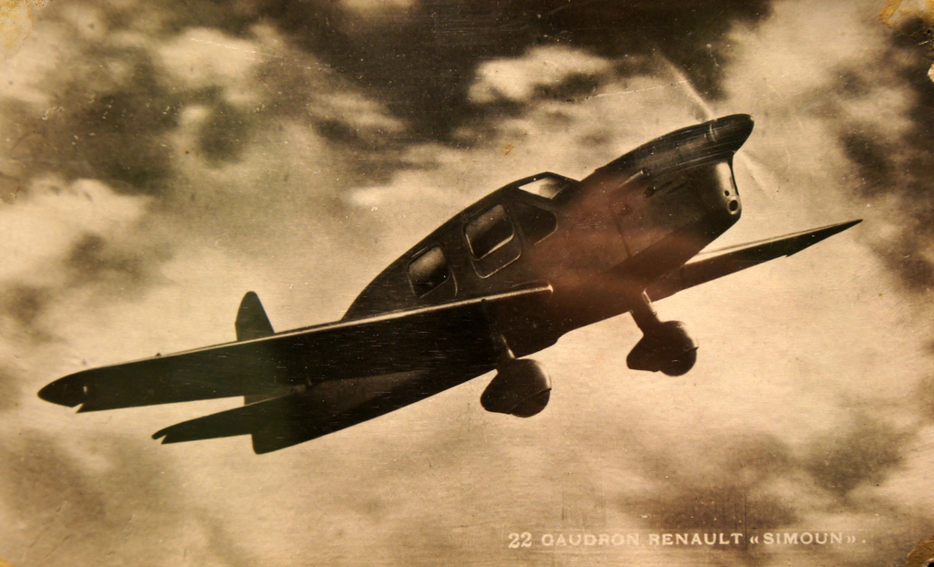

Figure 8: A Caudron Simoun similar to the one flown by Antoine de Saint-Exupéry [275],[^104] see Sec. 2.3.

## 2.1 Epistemology, Statistics and Machine Learning

### 2.1.1 The Parsimony Principle

Ockham’s razor is a well-known parsimony principle in philosophy [276]:

> Pluralitas non est ponenda sine necessitate.

(Plurality should not be posited without necessity). William of Ockham, a medieval friar, theologian, and philosopher, used it in several of his manuscripts for different purposes, the most important of which was to conclude that “God’s existence cannot be deduced by reason alone” [277]. However, this principle, despite its name, did not originate with him. It was well-known in Scholastic philosophy and can be traced back all the way to Aristotle. He wrote: “We may assume the superiority, other things being equal, of the demonstration which derives from fewer postulates or hypotheses” [278]. In more modern times, we find it restated in several variants, for instance, by Isaac Newton: “We are to admit no more causes of natural things than such as are both true and sufficient to explain their appearances” [277].

This bias for simplicity continues in modern statistics and data analysis. For example, John Tukey, a statistician who invented the Fast Fourier Transform and the boxplot, wrote [279]:

> The importance of parsimony in data analysis can hardly be overstated. By parsimony we mean both the use of few numerical constants and also the avoidance of undue complexity of form in summarizing and displaying. The need for parsimony is both esthetic and practical.

It isn’t just an experience-based statement. For instance, well-known model selection methods, such as the Akaike Information Criterion and the Bayesian Information Criterion, call for the minimization of a quantity that includes a term proportional to the number of parameters in a model. In particular, when the fit to the data is equally good, both methods will choose the model with fewer parameters.

Not everyone agrees. For instance, statistician and social scientist Andrew Gelman writes [280]:

> A lot has been written in statistics about “parsimony” — that is, the desire to explain phenomena using fewer parameters — but I’ve never seen any good general justification for parsimony. (I don’t count “Occam’s Razor,” or “Ockham’s Razor,” or whatever, as a justification. You gotta do better than digging up a 700-year-old quote.)  
> Maybe it’s because I work in social science, but my feeling is: if you can approximate reality with just a few parameters, fine. If you can use more parameters to fold in more information, that’s even better.  
> In practice, I often use simple models — because they are less effort to fit and, especially, to understand. But I don’t kid myself that they’re better than more complicated efforts!

Gelman sees parsimony as specific to physics, not as a general statistical or epistemological principle [281].

These two points of view aren’t compatible. I initially thought this could be explained by the existence of two major schools of thought in statistics, frequentist and Bayesian, with Gelman an exponent of the latter [282]. Broadly speaking, in frequentist statistics, the more parameters a model has, the better it fits the data. The statistician needs to actively counter this tendency to prevent overfitting, which is when a model can fit the signal as well as the noise, undermining its use, for instance, in prediction or parameter estimation. Intuitively, such a model “memorizes” past data, as opposed to capturing its regularities. In Bayesian statistics, all parameters are assumed to be drawn from a probability distribution, the prior, either because they are stochastic or to represent our preexisting state of knowledge or ignorance about them. This fact, in and of itself, is an antidote to introducing too many parameters. Let’s see how this works with an example of Bayesian model comparison [283]. $M_1$ models a fair coin with equal probability for heads or tails and no parameters. $M_2$ models a biased coin, with an unknown amount and direction of its bias, represented by a parameter also assumed to be a random variable. The probability of $M_2$, conditional to the data, is obtained by integrating over the possible values of its parameter, weighted with their prior probability. With a peanut butter analogy, $M_2$ is “spread thinner” than $M_1$ because all probability distributions are normalized to one. With a betting one, $M_1$ makes a sharp bet on a single parameter value, 1/2, whereas $M_2$ keeps its options open. In frequentist statistics, the bias parameter would be considered an unknown but not a random variable. It could be set to 1/2 if the data supported that, and there would be no way $M_1$ could fit the data better than $M_2$. The latter “contains” $M_1$ as a special case. Frequentists aren’t fools and have developed ways to fix that. However, for Bayesianists, the solution is built into their approach. Wikipedia concludes:

> $M_2$ is a more complex model than $M_1$ because it has a free parameter which allows it to model the data more closely. The ability of Bayes factors to take this into account is a reason why Bayesian inference has been put forward as a theoretical justification for and generalisation of Occam’s razor […].

Therefore, while the parsimony principle may be implicit in Bayesian statistics, it is compatible with it. Jefferys and Sharpening agree [284]:

> Ockham’s razor, far from being merely an ad hoc principle, can under many practical situations in science be justified as a consequence of Bayesian inference.

In the coin example, though, the prior probabilities of models $M_1$ and $M_2$ were arbitrarily set to the same value. Additionally, we glossed over the choice of prior for the bias parameter in $M_2$. These choices are mainly left to the statistician or researcher. This has often been cited as making Bayesian statistics inadequate for science, as conclusions are too dependent on the choice of prior — that is why its dominant variant is called *subjective Bayesianism* [285]. Bayesians reply with several counter-arguments, from the theoretical difficulties affecting frequentism to the existence of *uninformative priors*, which, at least in simple cases, lead to a convergence of Bayesian and frequentist results.

### 2.1.2 A Universal Prior

The question of the prior could be solved if we could find something like a *universal prior*. It would function as a proto-belief, the prior that predates all data collection and thus solves the Bayesian conundrum. Such a concept exists in a subfield called *algorithmic probability* [286]. As the name suggests, this is a research domain at the intersection of computer science and statistics. The foundational step is to consider statistical models as programs, not just because it is practical to run them on computers rather than with pencil and paper, but also because of advantages at a conceptual level. Traditionally, statistical models take the form of mathematical expressions, and it seems impossible even to contemplate the set of all possible models. Philosopher Elliot Sober states [276]:

> Unfortunately, the idea that we can now enumerate the set of all possible future scientific theories is illusory.

Suppose we instead confine ourselves to computable models, that is, those that can be expressed as terminating programs. In that case, even if there is an infinite number of them, each program is a finite object; therefore, they can be enumerated, at least in theory — their number grows exponentially with size. Moreover, bounding the size of a program-as-model provides a simultaneous limit on its parameters’ number and magnitude (or precision). This limits its complexity in a way agnostic to its nature (say linear vs. non-linear). An objection to the generality of this approach may be that even a simple linear model $y = ax$ may not be computable. It may be surprising, but most real numbers are *uncomputable*; that is, no computer can produce their digits to an arbitrary precision [287]. If the parameter $a$ in $y = ax$ were uncomputable, so would the model itself. However, since all measurements result in rational numbers, it is debatable if we will ever have to deal with such uncomputability barrier, or if it will forever remain as a potential problem. Indeed there are quantum-mechanic and information-theoretic arguments against the possibility of infinite-precision measurements [288].

It is possible to define a probability distribution over the set of computable models that we can use as a prior before any data becomes available. For a program of size $L$[^105] its a priori probability is proportional to $2^{-L}$. In other words, a model that is one unit larger than another is considered half as likely. Just the fact that we are able to proceed with this definition is progress, but we shouldn’t assume that reality bends to fit mathematics. Nonetheless, for the sake of this book’s thesis all we need to observe is that all alternative priors share the property that those represented by large programs are less likely than small ones in an aggregate sense. This result can be stated more precisely: for every $\epsilon>0$ there is an $L$ such that all models larger than $L$, in aggregate, have probability less than $\epsilon$. Therefore, no matter how we tinker with the prior, there is no way to rigorously state “prefer large models over small ones.” Let’s not overstate what this theorem means: it doesn’t lead to a unique choice of prior.[^106] Ray Solomonoff, one of the inventors of algorithmic probability, concedes as much in a relatively recent paper where he says he has come to think of this as a strength rather than a liability [289]. However, no prior can systematically prefer larger models over smaller ones. There is no way to escape parsimony, at least in this aggregate sense.

The next step is assuming that the process to be modeled is itself computational; that is, a program can simulate it. We could equivalently state that theories of the natural world can be expressed in a computable way without loss. This is a bit more of a leap of faith and I refer you to the work of Jack Copeland, Mark Sprevak and Oron Shagrir, where the question of whether the Universe is computational is addressed [290]. They examine several alternative answers: the Universe could be a computing device, albeit an enormous one; or, while non-computational, it could be effectively approximated by such a device; or, at least in some reaches we haven’t explored yet, it could be impervious to computational modeling. Either one of the first two answers allows us to proceed with our argument.

Now that we have a prior on programs which, hopefully, can effectively model Nature, deep mathematical results are possible, including the derivation of a prediction algorithm with an error bound depending only on the Kolmogorov complexity of the process to be modeled. Let’s recall that if such a process produces a certain sequence of observations $x$, its Kolmogorov complexity is defined as the length of the shortest program[^107] able to reproduce $x$ (see Sec. 1.2.11.1). Imagine a random $x$ generated by fair, independent coin tosses: the only way to reproduce $x$ is storing it toss by toss. Hence its length and its Kolmogorov complexity are similar in magnitude. At the opposite end, imagine $x$ is $000\ldots 0$ $\lvert x\rvert$ times. It is easy to build a short program repeating 0, at least if by “short” we mean $O(\log(\lvert x\rvert))$.[^108] The Kolmogorov complexity of these observations is much smaller than in the previous case. It is intuitive that a prediction method would perform better on the repetitive sequence as opposed the random one, and the above error bound formalizes that. The universal prior has other interesting properties that we can’t cover here and its presentation has been quite informal; therefore I encourage you to check the sources. Unfortunately, it isn’t appropriate for practical applications, or at least not yet. There are related approaches that are more so and also rely on short descriptions of data and models, as we will see in the next section.

### 2.1.3 Minimum Message Length

The relation between the size of statistical models and their performance is at the center of a model selection method known as Minimum Message Length [291]. Imagine we need to communicate a dataset over a transmission line and decide to send it in two parts: an encoding for a statistical model and then a separate encoding for the data, conditional to the choice of model, for instance, encoding only the error in the model prediction. Plug into this the Shannon-Fano code, which assigns a code length of $-\log P(x)$ to a code word $x$, and it turns out that minimizing code length is equivalent to maximizing the posterior probability $P(M) P(D|M)$, where the first part is the probability of the model and the second is the probability of the data given the model. Up to this point, this may look like a Bayesian take on model selection.[^109] However, the formulation in terms of encodings means that the models have to be expressed finitely, for instance, with finite precision numbers instead of real numbers, creating a bridge with algorithmic probability (see the previous section). This relation is explored in depth by Wallace and Dowe [291] and Vitányi and Li [292]. Here though, the class of models isn’t necessarily the class of all computable models but can be defined more flexibly in a problem-dependent fashion. Thus, we could restrict the space of models to finite precision linear models and apply Minimum Message Length to choose among competing ones, giving up on any universality claims but, at the same time, offering a more practical method. Vitányi and Li go so far as to state:

> It is widely believed that the better a theory compresses the data concerning some phenomenon under investigation, the better we have learned, generalized, and the better the theory predicts unknown data. This belief is vindicated in practice and is a form of “Occam’s razor” paradigm about “simplicity” but apparently has not been rigorously proved in a general setting. Here we show that data compression is almost always the best strategy, both in hypotheses identification by using an ideal form of the minimum description length (MDL) principle and in prediction of sequences.

The Minimum Description Length principle is an independently developed relative of Minimum Message Length which tries to free itself from the dependence on the availability of a prior [293]. The “ideal form” mentioned above is a bridge to the algorithmic probability of the previous section. These different lines of research point to the discretization of statistical models and the adoption of size, of either concise programs or concise codes, as a means to control complexity and, as a consequence, ensure good statistical performance.

### 2.1.4 Deep Learning

Neural networks, a biologically inspired class of statistical models, have gone through different phases of enthusiasm followed by disillusion as researchers explore their possibilities and limitations. In the 2000s, one of the growth phases started when it became possible to *train* — *fit* in more traditional statistical jargon — substantially larger networks than before, dubbed *deep neural networks* because of their structure organized in many layers [294]. These new systems broke performance records on several established AI benchmarks related to vision and language tasks. There was a consensus that scaling to larger networks and data sets was the most direct path to improved performance [295] and even general intelligence [296], a level at which man and machine become indistinguishable.

After a phase of rapid progress and exuberant optimism, we are now in one of diminishing returns. Autonomous driving is perennially a few years away from fruition. Google has been going at it for 12 years, yet its cars still struggle to make left turns in ideal conditions [297]. Moreover, machine learning systems are brittle to small changes in their statistical environment or deliberately generated examples to “trick” them into giving wrong answers, so called *adversarial examples* [294]. The best neural nets for natural language processing, known as *language models*, were trained from entire crawls of the internet, vast collections of digitized books, and more. It isn’t far-fetched to say that they ingested everything there is to read, yet their performance is uneven: superhuman on some tasks, disappointing on others [298].

One of the reasons may be that researchers focused too much on statistical performance at all costs, on achieving the coveted SOTA (State Of The Art, the best performance on a benchmark). Throwing more data and neurons at the problem was a reliable way to improve performance, but the rate of progress got overlooked. After observing a decade of progress, Sun and co-authors concluded that “performance increases logarithmically based on volume of training data” [299]. Otherwise stated, an additive improvement requires order-of-magnitude larger datasets and models and two orders of magnitude more computing power, as each data point needs to be processed by a proportionally larger network. The next step is multi-modal systems that process text, images, sound and video, and are trained to perform many disparate tasks [300]. Unfortunately, few well-funded labs can pursue this research, as enormous computational resources are needed.

Two major innovations that led to the current renaissance of neural nets are convolutional nets and deep nets, which, for the same size, show better performance than their non-convolutional and shallow counterparts. Paradoxically, ideas at the origin of the current size race are ways to squeeze more performance out of a system of a given size. Some researchers are starting to question the consensus and finding that smaller networks (still in the 10s of billions of parameters) trained on more data under a fixed computational budget perform better than some of the previous champions [301]. Others are looking again into data efficiency [302].

Deep neural networks seem as far as possible from the concept of parsimony. They include hundreds of billions of adjustable parameters, a large number even considering the giant data sets on which they are trained. Theory and experiments show they should overfit the data but, in practice, they don’t, and researchers are trying to figure out why [303]. In one case, they created abridged versions of large networks without significantly changing their performance [304]. This wasn’t done for practical reasons, such as deployment onto mobile devices [305], but to prove that the larger networks provided good predictions, like their smaller versions. We could say that the parsimonious models were hiding inside the verbose ones.

### 2.1.5 Extreme parsimony

Ockham’s razor warns against complex explanations beyond what is necessary (see Sec. 2.1.1). Different thinkers and researchers have provided different definitions for “complex” and “necessary,” resulting in various principles and methods. However, an ancient philosopher, Parmenides, stands out for simply dropping the “necessary” part of the razor and reducing his theory of everything to a bare minimum of complexity. He embraced a tautology — “whatever is is, and what is not cannot be” — to the extent that he denied the existence of anything other than an undifferentiated being and considered all perception an illusion [306]:

For this [view], that That Which Is Not exists, can never predominate. You must debar your thought from this way of search, nor let ordinary experience in its variety force you along this way, (namely, that of allowing) the eye, sightless as it is, and the ear, full of sound, and the tongue, to rule; but (you must) judge by means of the Reason (Logos) the much-contested proof which is expounded by me.

Ancient and modern philosophers provided many interpretations of Parmenides’ thought, which we know only through fragments of his writings or indirect sources [307]. Among those, the most appealing to me is the most extreme, known as *strict existential monism*. According to it, only one entity exists, while every distinction, every difference, and becoming itself must all be an illusion. I associate this barebones ontology with other expressions of extreme minimalism, some of which appear in this book: the empty software module (see noop2 in Sec. 1.2.2), the paintings showing a single square (see Malevich’s squares in Sec. 3.2.3), and the silent piece of music (see Cage’s 4’33” in Sec. 3.3). As for those, it is possible to suspect Parmenides’ philosophy of being a prank for intellectuals. However, his current standing as the father of ontology 2500 years later suggests the opposite.

## 2.2 Mathematics

Being the first to devise a proof for some important conjecture or open problem provides the most recognition and notoriety, independent of its length. Take Andrew Wiles’s proof of Fermat’s last theorem [308]. This theorem has a deceptively simple formulation. We know there are right triangles with integer-length sides, for instance, 3, 4, and 5, and, by Pythagoras’ Theorem, $3^2+4^2=5^2$. Since mathematicians like to try and generalize simple concepts, the problem was expanded as follows: are there positive integer solutions to $a^n+b^n=c^n$? Solutions for $n=1,2$ were known since antiquity, but none for $n\ge3$. Fermat stated he had proved that none existed. His proof being lost or maybe only imagined, his statement stood as a conjecture to the attention of the greatest mathematicians for centuries, but progress was halting: Fermat himself proved the $n=4$ case, which implies further work need only focus on prime exponents.[^110] Then $n=3,5,7$ fell, followed by entire classes of primes. However, the general proof was considered untouchable by most mathematicians. Wiles’s solution took years to put together while also building on voluminous work by other mathematicians, who had created bridges between distant fields in mathematics. When first announced, it took a three-day workshop to explain; when published, after some errors were found and corrected, a full issue of the Annals of Mathematics. It is no lightweight proof, but the problem is solved, and prizes and honors have been bestowed on Wiles. Nonetheless, other mathematicians have already started simplifying it. This type of work is also valued, albeit not as celebrated as the first proof of an original result. For instance, reporting on the award of the Field Medals, the highest recognition in Mathematics, to Peter Scholze, Kenneth Chang writes [309]:

> Dr. Scholze gained prominence when he was still in graduate school in 2010, simplifying a complicated book-length, 288-page proof to a novella-size 37-page version.

That more svelte proof did not earn Scholze his Field Medal, though. Instead, it was his work at the intersection of number theory and geometry, where he made several original contributions that spurred new lines of research. Novel and fertile for novel results beat concise.

If long proofs are acceptable, is there a limit? When is a proof too long to be checked accurately? One case stretching the boundary is that of the four-color theorem. It is another deceptively simple statement about coloring maps. Specifically, we are concerned with political maps and the assignment of colors to each state or country. It is required that no two bordering states be assigned the same color. Corner contact such as that between Utah and New Mexico doesn’t count. The theorem states that four colors are enough for any map, real or imagined. Kenneth Appel and Wolfgang Haken published a hybrid proof, with a section written by them and another generated by a program [310]. It wouldn’t have been feasible for humans to perform an exhaustive check on thousands of cases to which the original statement was reduced. Not only did such a proof create a certain amount of controversy, but it also managed to conceal some errors for at least four years. The authors finally rectified these errors in a book, including a computer-generated 400-page appendix. Flawed proofs weren’t unprecedented for this problem: two previous ones, of a more traditional kind, had each withstood scrutiny for 11 years before unrecoverable errors were discovered. The controversy about the recent proof was partly because checking it was beyond human ability. Indeed, mathematicians directly verified the program that wrote the more repetitive part of the proof. Therefore, why not publish that program instead of its 400-page output? I guess that would have been an even more radical innovation. Moreover, some mathematicians find such verbose proof doesn’t help in understanding why this theorem is correct, a somewhat vague complaint. As mathematician and pioneering computer scientist John Von Neumann said: “In mathematics you don’t understand things. You just get used to them,” recognizing that modern mathematics is past a level where intuition is helpful [311].

The four-color theorem is neither unique nor the record holder for size. Wikipedia maintains a list of long proofs, with the length of the worst offender estimated to be between 10,000 and 20,000 pages long [312]. I don’t know if this count includes only one proof or is comprehensive of independent results used as stepping stones.

The prolific mathematician Paul Erdős believed the most elegant and concise proofs come from a mythical book he referred to as *The Book*. He reportedly said: “You need not believe in God, but, as a mathematician, you should believe in The Book.” Its earthly materialization came into existence in 1998: *Proofs from The Book* [313]. Its authors, mathematicians Günter Ziegler and Martin Aigner, explain that there are many criteria to pick a proof for the book: its clarity, innovative ideas and ability to reveal something new about the problem. However, there is a clear-cut criterion: “A proof that eats more than 10 pages cannot be a proof for our book” [314]. The authors readily admit that there could be perfect proofs that are longer than ten pages, but they aren’t sure they are within human reach.

## 2.3 Engineering and Design

In branches of engineering outside computing, as we have mentioned (see Sec. 1.2.1), there is built-in pressure towards lowering the part count and the materials bill, as well assemblage costs. Therefore it is harder to identify or even clearly define any ascetic tendencies. However, some designs accomplish more than the sum of their parts. For example, in the *Car of the Century Award* ranking, of the top five cars, three are entry-level models that made driving accessible to large swaths of the population for the first time: the Ford Model T, the BMC Mini, and the Volkswagen Beetle [315]. Notably missing from the top five is “the most intelligent application of minimalism ever to succeed as a car,” the Citroën 2CV [316]. Yet the 2CV stayed in production longer than any other model, a record 42 years, graduating from a practical vehicle for farmers to a lifestyle statement.

Likewise, in the evolution of the airplane, simpler shapes are primarily the result of aerodynamic or structural constraints. Yet Antoine de Saint-Exupéry, writer and aviator of the pioneering age (see Fig. 8), found that simplicity was a unifying theme in all engineering endeavors and shared with natural forms. He wrote [317]:

> In anything at all, perfection is finally attained not when there is no longer anything to add, but when there is no longer anything to take away, when a body has been stripped down to its nakedness.

This idea seems to have taken hold in modern industrial design, as demonstrated, for instance, in the work of Dieter Rams, the designer behind iconic small appliances and electronic devices made by consumer product company Braun in the 50s and 60s, like the T3 radio, the cylindrical table lighter or the PS2 turntable [318]. The last, but hopefully not least, of his ten design principles is that “Good design is as little design as possible” [319]. This restrained approach resulted in designs that rise above the ebbs and flows of fashion and have aged gracefully, even as technology has made them obsolete. Moreover, these principles were in the service of other goals, including durability. In a recent documentary dedicated to him, Rams expressed his condemnation of the rapid replacement rate of modern technology [320].

If designing with fewer parts is now mainstream, fixing artifacts by removing parts isn’t, as we have seen for computer programs. Psychology research supports the idea that people, facing a broken device, think of adding parts rather than removing them: a piece of tape here, a screw there [321]. The same research finds that subtractive solutions are often overlooked in various tasks, from essay writing to itinerary definition.

Even if engineering has a built-in pressure towards reducing part counts, there are spectacular exceptions. Brick houses require roughly eight bricks per square foot of habitable surface, often exceeding 10,000 bricks for a typical US house.[^111] Small bricks take more time and mortar to lay but, as long as unassisted workers perform the job, there are limits to the size they can use. Consider how many other aspects of manual work are assisted by power tools: bricklaying isn’t one of them, save for mortar preparation.

At least a home can be built with one or a few types of bricks. Their number may be in the five figures, but the parts are interchangeable. Quite the opposite is true for the Eiffel Tower, which is made of 18038 metal parts described in 5329 drawings [322]. Two factors contributed to this inflation of unique elements: a limit on the weight that could be lifted up the tower during construction and its curved profile, based on Eiffel’s calculations for optimal wind resistance [323]. While the tower’s design is simple, it did not result in a significant amount of modularity.

## 2.4 Biology

The question of whether biology favors conciseness is too big to handle here. Yet, when talking about genomes, size seems highly variable and not associated with essential characteristics of an organism. Sure, viruses tend to have smaller genomes than bacteria, and these, in turn, smaller ones than multicellular organisms, but there are wild variations even between closely related species. Add to that that we don’t know what most of the genome’s function is and that it is generally believed to include a lot of filler or detritus collectively dismissed as *junk DNA*. Nonetheless, the parts of unknown function have been slowly shrinking. Mappings for regulatory regions, small RNAs and more have been slowly added to the better-understood mapping for genes. Shrinking doesn’t mean disappearing, though. In 2004, Nobrega and co-authors showed they could remove two megabases of the mouse genome that are devoid of protein-coding genes and grow perfectly viable (“indistinguishable,” as they report) litters of mice [324]. Then, one glorious day, the vast majority of the human genome was declared functional — the opposite of junk — by the researchers of a mega-project named ENCODE[^112] [325]. Never mind it later emerged that its principal investigators were debating among themselves whether to make the top-line figure 20%, 80%, or anything in between, a telltale sign of an arbitrary number not supported by evidence. The chief bioinformaticist on the project, Ewan Birney, wrote, in a strangely naive confession, that they selected the higher figure because it “best conveys the difference between a genome made mostly of dead wood and one that is alive with activity” [326]. This statement should make clear beyond doubt that these numbers aren’t estimates of anything; they are instead messaging tools in a propaganda war for more funding. And funding do they need: the ENCODE project burned through roughly 400 million dollars, a significant portion of the NIH budget that couldn’t be awarded to “normal” research, and multiple follow-ups are already planned [327]. Jumping on the ENCODE bandwagon may become the only way to keep a laboratory open for a young investigator. Nature could not sit idle in the face of this travesty and made available an incredibly concise genome, that of a little carnivorous plant, *Utricularia gibba*, which has mostly eliminated anything in its genome that isn’t directly related to genes [328]. These are the types of genomic elements the ENCODE project newly claimed as functional, only working on human samples. If you are thinking about *homo sapiens* exceptionalism and hypothesize these mysterious genomic regions may be related to higher cognitive functions or free will, I will have to disappoint you. Consider, as a comparison, the common tomato, a not-so-distant cousin of Utricularia, with which it shares an 87 million years old ancestor. While the number of genes in the two genomes is similar, tomato’s size is ten times Utricularia’s and is packed with the same filler abundant in the human genome. That something that evolution can dispose of so quickly, in evolutionary time, could be of the utmost importance in both tomatoes and humans defies credulity [329]. Discovering a single plant genome lacking all protein-coding genes would revolutionize biology, but we won’t because genes are essential to an organism. Concise genomes may not be advantageous for life, but they sure helped us understand it.

# 3 Literature, Visual Arts and More

[figure not shown]

Figure 9: Blue and Green Music, 1921, by Georgia O’Keeffe [330],[^113] see Sec. 3.2.3.

> Anything expressed just right, whether it’s being really concise or just capturing it — like anything, a really well-put-together sentence or a little doodle, a caricature that looks just like someone but only used four lines, that kind of thing …

This is how Jamie Zawinski, a programmer best known for his role in creating the Netscape Browser, explains beauty in code [14]. It provides a perfect transition from engineering and science into the arts.

## 3.1 Speaking and Writing

### 3.1.1 Concise Writing

Calls for conciseness in writing abound and come from writers of all types. For example, *The Elements of Style*’s author William Strunk Jr. writes [331]:

> Vigorous writing is concise. A sentence should contain no unnecessary words, a paragraph no unnecessary sentences, for the same reason that a drawing should have no unnecessary lines and a machine no unnecessary parts.

*The Elements of Style* is itself an concise book. E. B. White, author of its second edition, describes it as “[…] a forty-three-page summation of the case for cleanliness, accuracy, and brevity in the use of English” [332].

Atwood joins the praise for this book [333]:

> There is perhaps no greater single reference on the topic of writing than Strunk and White’s The Elements of Style. It’s one of those essential books you discover in high school or college, and then spend the rest of your life wondering why other textbooks waste your time with all those unnecessary words to get their point across.

The Star Copy Style sheet, used at *The Kansas City Star* newspaper, warns to “use short sentences […] short first paragraphs” and to “eliminate every superfluous word” [334]. Ernest Hemingway, who worked there as a reporter, credited it for “containing the best rules I ever learned for the business of writing.”

However, writing short sentences doesn’t necessarily produce short books. Hemingway proposed the *iceberg theory of omissions* [335]:

> This [the real ending] was omitted on my new theory that you could omit anything if you knew that you omitted and the omitted part would strengthen the story and make people feel something more than they understood.

(The iceberg metaphor was introduced elsewhere). To buy into conciseness, you don’t need to be a Nobel Prize winner. Dru Riley, author of a popular newsletter, makes conciseness itself a goal [336]:

> People don’t realize constraints breed quality, and without constraints you just have a lot of noise. Some weeks I’ll write 13,000 words and I have to distill it down to less than ten percent of that. […] The goal is for the final report to be concise, dense, and readable.

Blogger Mike Crittenden supports reducing the number of ideas or sentences down to one [337]:

> There’s no law that says a blog post needs more than one idea or more than one sentence.

Software developer Bruce Eckel doesn’t consider any length too short [338]:

> Less is More. The more words you have, the more work your reader must do. Shorter sentences are easier to read and understand.

I am not sure Eckel strictly follows his own rules: the post this quote is taken from has more than 2500 words and takes roughly 16 minutes to read. However, I can’t prove they weren’t necessary.

Having the right goals is already helpful. For example, Jonathan Maltz made conciseness his new years’ resolution [339]:

> Biggest one for me in 2020 was succinct written communications. I look back at stuff I’ve written in the past and I’m embarrassed by how many words I wasted.

Even computer programs encourage conciseness, and I don’t mean that of their source code, which is covered in the first part of this book. For example, the text editor Zettlr offers an assist mode to improve a writer’s style. Its “algorithm will give you text credits for short and concise sentences,” among other style criteria [340].

Remember *Javascript: The Good Parts*, the book about subsetting JavaScript to make it better (see Sec. 1.3.2)? For a double dose of conciseness, that book is only 100 pages long. Olano writes [202]:

> Sometimes, a lot of the times, less is more. The book itself is the perfect example: 100 pages long, mostly filled with snippets and examples, and still it had a clearer purpose and communicated it more effectively than most computer books.

What about speeches? Let’s learn from Lord Pannick, counsel for the prosecution in a United Kingdom Supreme Court hearing about an unprecedented suspension of parliament [341]:

> [Lord Pannick’s] delivery was smooth and unruffled. Never using two words where one would do.

The counsel for the Government, Lord Keen, was less in a hurry:

> He began by spending 20 minutes arguing there was no difference between Scottish and English law in this case. This left people scratching their heads as no one had previously said there was.

The prosecution prevailed.

Four words can make a poem. The complete text of Italian poet Giuseppe Ungaretti’s *Mattina* roughly translates to “I shine / of immensity” [342]. I am not sure he got his point across, but I don’t think he was concerned about being intelligible. He was an exponent of the hermeticist literary current, thus named for its use of obscure metaphors. A draft, written on a postcard sent from the war front, was found to contain five verses, later reduced to two in the published version. To put such a short poem in context — short even by his standards — we need to consider that each word was vital for him and selected after a painstaking process. In *Commiato* he writes [343]:

> Quando trovo  
> in questo mio silenzio  
> una parola  
> scavata è nella mia vita  
> come un abisso

(When I find / in this silence of mine / a word / it is dug into my life / like an abyss). Fittingly, he read his poems at a deliberate pace [344].

### 3.1.2 Reducing Text

Sometimes it is possible to compare a text in long and short forms. What better opportunity to evaluate the merits of conciseness?

In a review of director Simon Godwin’s *Romeo and Juliet*, New York Times’s Jesse Green writes [345]:

> At 90 minutes, it is even shorter than the “two hours’ traffic of our stage” promised in its first lines but rarely honored in performance. (The entire play normally takes about three hours.) Yet […] this […] version scores point after point while whizzing past, or outright cutting, the elements that can make you think it was written not by Shakespeare but by O. Henry on a bender.

> If the cutting merely left what remains with a much higher proportion of penetrating insight and powerful feeling, that would be enough […]. But the speed serves another function here: telling a story that’s mostly about teenagers with a teenage intensity and recklessness.

It seems that in this case, paraphrasing McLuhan, the length of the medium is the message.

Revisions of a poem or novel may provide insights into how its author sees length. Poems come in all shapes and sizes, from single-verse fragments to multi-page odes. It is thus reasonable to think that there is little external pressure towards conciseness. Yet, in the case of “The Waste Land” by T. S. Eliot, the drafts of the poem show that it lost about half of its lines before being published, partly on the advice of fellow poet Ezra Pound [346].

State of the Union speeches by American Presidents also vary considerably in length. Yet, Cody Keenan, President Obama’s chief speechwriter in his second term, stayed up all night to perform some trimming [347]:

> By 5 a.m., a more succinct draft was on its way to the president.

Researchers often chafe at the strict paper length limits enforced by some journals. Not Mark Blaxter, professor of genomics, who was able to recognize that there were also advantages [348]:

> I was shocked at how much of our carefully crafted text could be pruned […] to leave only the essential core of what had to be said. Many a choice turn of phrase and illustrative simile had to be sacrificed to precision, flow and brevity. This was (probably) a good thing.

Other writers even enjoy the process. For example, Pamela Erens, author of the novels *The Virgins* and *The Understory*, writes [349]:

> My favorite part of writing is taking stuff out. […] when I can remove a limp adjective or superfluous sentence from a novel chapter or essay, I feel a rush that is a bit like being airborne.

### 3.1.3 Conciseness is Hard

When we run into verbose writings or speeches, we should cut the author some slack, because being concise is hard. “I would have written a shorter letter, but I did not have the time” wrote philosopher Blaise Pascal — this quote has also been misattributed to a half dozen other intellectuals [350].

Blogger Mike Crittenden, selecting quotes from his favorite reads for the year, can’t settle on a single one: “I couldn’t pick just one favorite quote from it, so here are two” [351]. It may sound tongue-in-cheek, but it makes sense that the decision between the top two options could be the hardest, as those are closest to the optimum than any other. A mathematical parallel is choosing an element for each of the sets in a collection. The possibility to do so for infinite ones rests on the axiom of choice, which is independent[^114] from the other axioms of set theory, and was initially looked upon with suspicion by mathematicians [352]. Luckily no one has read an infinite number of books, so picking one quote from each does not rest on this axiom.

President Obama, who asked his speechwriter to shorten his State of the Union address (see the previous section), wasn’t as good with his memoir, which exceeds 500 pages [353]. He said [354]:

> [I am] painfully aware that a more gifted writer could have found a way to tell the same story with greater brevity ([…] a signed copy of the 272-word Gettysburg Address rests inside a glass case)

Even computers find conciseness hard. For example, researchers working on GPT-2, a record-setting AI system to process natural language, reported [355]:

> Fine-tuning for the stylistic continuation tasks is sample efficient: 5,000 human samples suffice for strong performance according to humans. For summarization, models trained with 60,000 comparisons learn to copy whole sentences from the input while skipping irrelevant preamble.

In other words, plausibly extending a text was easier for this AI system than summarizing it.

### 3.1.4 The Law

The text of the law, in the United States as well as in many other countries, is ponderous, to put it mildly. Just the Affordable Healthcare Act alone takes close to a thousand pages. How are we supposed to access healthcare knowing our rights and obligations? Even attempting a count of federal laws is considered futile by the experts at the Library of Congress [356]. The complexity of the law, fueled by its size, jargon, and ambiguous language, forces people to rely on lawyers to interact with the justice system and each other. This is a source of discrimination between those who can afford to hire the best and the rest.

In an interview, Google co-founder Larry Page said he “would dearly love all laws to be limited to 50 pages. Every time a new law is enacted an old one should be removed” [357]. It can be easily dismissed as a billionaire’s delusion, but if we accept that ignorance of the law isn’t excusable, then a limit on its length should follow as a corollary.

I couldn’t find statistics on private contracts, but, in my experience, they are always too long. Lawyered-up companies try to gain the upper end on smaller ones or private citizens by overwhelming them with long and complex contracts or user agreements, sometimes exceeding 20,000 words [359]. Here is one refreshing exception, though. An energy startup, Voltus, offers one-page contracts and asks: “Could we make all contracts one page?” [360].

### 3.1.5 Counterpoint

This book was never meant to be an unbiased take on conciseness, but I would be remiss if I didn’t mention that there are texts, specifically novels, of incredible heft. According to Wikipedia, the record holder is *Venmurasu* for an estimated 3,680,000 words [361]. I am not laying an accusation that it is verbose: according to its author, it paints “a canvas as big as time itself,” a demanding task. The first English entry, *A Chronicle of Ancient Sunlight* by Henry Williamson, is a distant second with 2,436,924 words. In both cases, it may be arguable that they are cycles of novels rather than a single one. There are about ten entries over a million words. All these will likely be eclipsed by Richard Grossman’s *Breeze Avenue*, a collective multi-media work expected to total three million pages [362]. Not so much a novel as a “band of meaning impelled by forces analogous to those that undergird physical reality,” it is planned to “emanate,” every 36 days, “a one-of-a-kind 5,000-page evanescent novel.” Five thousand of these works are scheduled over five hundred years, each published online for a short time. The Guinness book of records must employ a tighter definition of a novel, as they list as the current champion Marcel Proust’s *Remembrance of Things Past* [363], totaling 1,267,069 words in 7 volumes [364]. I do know people who credibly claim to have read all of it.

One thing is writing unrepentantly long novels, and another is belittling conciseness. Cegłowski’s blog byline is “Brevity is for the weak,” without further explanation [365]. His most-read posts have an average length of about 3500 words for a reading time of 15-20 minutes. There is no contradiction, though, with his views on web design (see the “web obesity crisis” in Sec. 1.5), as his pages are only rich in text and load almost instantly.

## 3.2 Visual Arts

### 3.2.1 Architecture

We have mentioned in the Introduction that “Less is more” is an aphorism for frugality. While this concept does not originate with architect Ludwig Mies van der Rohe, it is most commonly associated with him, whose work was characterized by “extreme clarity and simplicity” [366]. He is regarded as one of the pioneers of modernist architecture, and the same minimalistic attitude guides the whole movement. Some maybe took it a little too seriously, as the title of Adolf Loos’ essay *Ornament and Crime* suggests [367]. He knew something about crime, being convicted of one later in life.

### 3.2.2 Photography

Alfred Stieglitz is credited with driving the acceptance of photography as an art form with his pictures as well his work as a promoter [368]. His style was aimed at drawing as clear a distinction as possible between photography and painting:

> Stieglitz described his most recent work as ‘intensely direct. … Not a trace of hand work on either negative or prints. No diffused focus. Just the straight goods. On [some things] the lens stopped down to 128.[^115] But everything simplified in spite of endless detail.’

In particular, he was reacting to an early photographic movement known as *pictorialism*, which emphasized staged subjects and effects. Stieglitz instead saw photography as fundamentally anchored in reality.

Reality can be messy, but the photographer, no matter how direct his technique is, still exercises control over when, where, and in what direction to shoot, which results in the inclusion or exclusion of some visual elements. Landscape photographer Huntington Witherill sees this selection as fundamental [369]:

> Finding the strongest way of seeing is really, to my way of thinking, intellectualizing within myself what it is that attracted me to the scene in the first place. And then, doing my best to include all of that within the photograph itself and eliminate everything else out of the photograph.

Editing a shot is an available artistic choice in most genres of photography, but not in photojournalism, where it is strictly limited to keep a picture true to reality. When Steve McCurry, one of the most celebrated photojournalists of his generation, was found to have routinely and secretly edited or even staged his, a scandal erupted [370]. Even the famous *Afghan Girl* has been published in at least two versions, one more “cleaned up” than the other. Inspection of several edited images reveals that removing distracting elements and enhancing colors are the most common transformations, a window into the thinking of a great photographer, if no longer a photojournalist, as he now fashions himself a “visual storyteller.”

The virtues of visual simplicity are evident not only to outstanding photographers but also to regular professionals. For example, real estate and landscape photographer Anton Gorlin doesn’t mince words [371]:

> Take it this way — if it doesn’t add to the story, exclude it. You got it right — include as little as possible.  
> Indeed, to build great compositions, you must learn to exclude with no remorse or regrets. […] Always aim to include as little as possible.

Magnum Photos photojournalist Jerome Sessini takes one further step [372]: “I look to make photos better by subtraction rather than addition.” He acknowledges that his style evolved towards conciseness but that, initially, he was “introducing the maximum number of elements into the frame” following the example set by two of his role models (see Gilden in Sec. 3.2.4).

### 3.2.3 Painting

Compared to photography, painting affords the artist the highest degree of control and, specifically, the freedom to include any number of elements or details in an image. Georgia O’Keeffe, a painter (see Fig. 9) personally and professionally related to Stieglitz (see Sec. 3.2.2), advocated including fewer of them [373]:

> Nothing is less real than realism. Details are confusing. It is only by selection, by elimination, and by emphasis that we get at the real meaning of things.

O’Keeffe’s quest isn’t just aesthetic but one for meaning. Her words suggest an analogy with statistics (see Sec. 2.1.1). Over-fit models can reproduce every minute detail in the data but, unable to distinguish the signal from the noise, fail to capture the laws governing the system under consideration — a failure seen in their inability to generalize to new data points.

“Art is the elimination of the unnecessary,” said Picasso [374]. Or did he? Despite the abundance of attributions on the web, I couldn’t find one pointing to a source, and exact matches in online searches are all dated 2000 or later. An earlier variant read: “Design is the elimination of the unnecessary.” It probably seemed like a good aphorism, just needing a prestigious, if inauthentic, voice.

Nonetheless, Picasso was familiar with self-imposed limitations [375]:

> For a long time I limited myself to one color — as a form of discipline.

He is probably referring to his blue and rose periods — they are two distinct periods, one for each color — during which he used severely restricted palettes, arguably matching his dominant mood at that time.

His contemporary Henri Matisse applied minimalism not just to the color but to every element of a painting [376]:

> In a picture every part will be visible and will play its appointed role, whether it be principal or secondary. Everything that is not useful in the picture is, it follows, harmful. A work of art must be harmonious in its entirety: any superfluous detail would replace some other essential detail in the mind of the spectator.

As with music (see 4’33”, Sec. 3.3), it is possible to push simplicity to its extreme consequences, and I suspect nobody represents that possibility better than Kazimir Malevich. He is known, among other works, for his trifecta of paintings depicting just one square each: *Black Square*, *Red Square*, and *White on White*. Peter Schjeldahl, an art critic, wrote [377]:

> Malevich is monumental not for what he put into pictorial space but for what he took out: bodily experience, the fundamental theme of Western art since the Renaissance.

This statement places Malevich at the forefront of abstract art, but I think he was another few steps ahead. Corresponding about *Black Square*, Malevich wrote: “It is from zero, in zero, that the true movement of being begins” [378]. To me, *White on White*, a painting representing, unsurprisingly, a white square on an otherwise empty canvas, is even closer to zero, with its minimal amount of contrast. Malevich seems to be asking how abstract art can be and what can’t be left out of a painting. He stops right on the edge of answering: “nothing.” Like the silent piece 4’33” but unlike their less famous precursors (see below), Malevich’s squares have stood the test of time, are still displayed in exhibits around the world, and have a place in the history of art.

Hidden under the paint of *Black Square*, there is a reference to similar, earlier pieces by French humorist Alphonse Allais. He produced several monochrome canvases, filled edge-to-edge with the same color, and a silent funeral march, all satirical works [379]. Allais did not author the first published black square, though. As far as I know, that distinction goes to Paracelsian physician Robert Fludd in his 1617 *The History of the Physical and Metaphysical Cosmos*, where, among a set of 60 detailed engravings, it appears as an illustration of infinite darkness, the primordial state before creation [380]. It seems that, for Malevich’s squares, timing and context were as consequential as the artwork itself.

### 3.2.4 Counterpoint

I would be remiss if I didn’t reference some counterexamples to conciseness in the visual arts. Talking about the photography of Jerome Sessini (see Sec. 3.2.2), I mentioned that he moved away from a more crowded style that had been inspired by two of his role models, Mark Cohen and Bruce Gilden. After researching their work, I could find only a few examples of such style in Gilden’s work (for instance, [381] from *Coney Island* [382]). His images include multiple subjects, none clearly more important than the other, filling the frame, with no background-to-foreground separation. They seem to represent a small fraction of his work [383]. We can find this style thoroughly embraced by the Flemish Renaissance masters Hieronymus Bosch (*Garden of Earthly Delights*; *Triptych of the Haywain*) and Pieter Bruegel the Elder (*Carnival and Lent*; *Proverbs* [384]) or French engraver Jean Duvet (*Fall of Babylon*; *Apocalypse* [385]). The latter’s work, in particular, can be considered an example of *horror vacui*, the fear of or distaste for empty space. Originally a term used in physics dating back to Aristotle, it was later associated with Victorian architecture as a pejorative. Baroque architecture also makes extensive use of ornamentation to avoid empty space. An artistic need to fill all the available space predates all of these examples, going back at least to the Geometric Age in Greek art. However, that style, like the Islamic arabesque, seems to prefer orderly patterns to Duvet’s complex, almost chaotic arrangements.

## 3.3 Music

Music, like literature, doesn’t seem constrained by particularly severe length limits, with compositions lasting minutes, several hours, or anything in between. Namely, classical music, with its planned repetitions and taste for variation, seems bent on keeping the music going. Particularly during the romantic period, which saw the premiere of Beethoven’s *9th Symphony* — 70 minutes — or Richard Wagner’s opera *Die Meistersinger von Nürnberg* (The Master-Singers of Nuremberg) — 5 hours and fifteen minutes — it seems conciseness wasn’t an important consideration. Yet Franz Liszt, in his praise of Robert Schumann’s *Carnaval*, wrote [386]:

> [Carnaval] will assume its natural place in the public eye alongside Beethoven’s Diabelli Variations, which in my opinion it even surpasses in melodic invention and conciseness.

Hungarian composer Béla Bartók, who devoted much of his work to the study of folk music, wrote [387]:

> [Folk music] is the classical model of how to express an idea musically in the most concise form, with the greatest simplicity of means, freshness and life, briefly yet completely and properly proportioned.

Moving closer to contemporary music, the work of Anton Webern stands out for its brevity. “Webern’s compositions are concise, distilled, and select; just thirty-one of his compositions were published in his lifetime,” Wikipedia reports [388]. A comprehensive recording of his *opera omnia* fits 6 CDs, and “the Six Bagatelles for string quartet (1913), for instance, last about three minutes in total.” Contemporary composer Arnold Schoenberg, whom Webern reciprocally influenced, described his musical aesthetics as follows: “My music must be brief. Concise! In two notes: not built, but ‘expressed’!!” Later, though, he deviated from this more clearly Webernian ideas.

An alternative to writing short pieces of music is removing the sound. John Cage achieved this with his *4’33”*, in which any ensemble performing it is instructed not to make a sound [389]. It wasn’t an original idea, being preceded by half a century by *Il Silenzio: pezzo caratteristico e descrittivo (stile moderno)* (Silence: characteristic and descriptive piece (modern style)), pseudonymous work tentatively attributed to Edgardo Del Valle de Paz [390]. However, unlike its predecessors, it was meant to be taken seriously. Cage hesitated to “write it,” concerned it would be considered a prank. Whereas the function of computer programs or buildings is relatively clear, music doesn’t have an obvious one. Is *4’33”* a concise piece of music? Or does it take that much time to accomplish nothing, like a computer program spinning idle (see the busy beaver numbers in Sec. 1.2.11.1 for interesting yet idle programs)? Or are 4’33” of quiet time to take in background noise or just think the goal? I don’t have a definitive answer but 4’33” has worked like a music piece. It has been recorded, performed in front of an audience, and its score is available for purchase. As for Malevich’s squares (Sec. 3.2.3), it seems like the timing and context of the work have to deal with its success more than the actual “music.”

While revolutionary, the first “serious” silent piece didn’t leave room for many follow-ups, even if Cage himself wrote two of them, *0’0”* and *One<sup>3</sup> = 4’33” (0’00”) + 𝄞*. Don’t rush to publish your own 4’32” or 4’34” and hope to wow audiences and critics the way the original did. However, other approaches to minimalistic music don’t require sound to shrink or disappear, only the score. Terry Riley’s *in C* shows one possibility [391]. While this piece takes only one page of musical notation, its typical performances last 45 minutes to an hour. It specifies 53 *loops* or phrases to be repeated and combined according to somewhat loose instructions that allow performers a lot of discretion. These instructions are related to the canon, a traditional form prescribing that phrases be performed in the order they are written, with staggered starts for each instrument. Unlike the canon, performers are allowed a variable number of repetitions for each phrase. The result is a repetitive but ever so slightly changing mass of sound, strangely suspended between the calm and frantic, forever stuck in a single harmony, as the title suggests — which is one of the choices that allow so much performance freedom, like the fixed tempo. Unlike the silent piece, this approach allowed for many variations, attracted several composers, and became known as *minimal music* [392].

## 3.4 Management

Ascetic management sounds like an oxymoron. Leadership is about getting more done, conquering new markets, vanquishing the competition, and so forth. In this context, you may think of the lean startup, but that is penny-pinching rather than asceticism [393]. Nonetheless, a few isolated voices sing to a different tune. Jotform founder and CEO Aytekin Tank believed in the classic entrepreneur busyness bug: “constantly be building, working, growing and developing the next thing” [394]. Then he started seeing that being busy and being successful aren’t equivalent, and he decided that it was time to have some downtime. “But, doing less or nothing at all is easier said than done,” he writes. He almost echoes photographer Saul Leiter who wrote [395]: “I have a great respect for people who do nothing.” Or singer-songwriter Franco Battiato [396]: “Si salverà chi non ha voglia di far niente, non sa fare niente” (Those who don’t feel like doing anything, who don’t know how to do anything will be saved). Tank primarily faults societal pressure to look constantly busy for his inability to slow down. The remedy he adopted, following the likes of Bill Gates, is to take a block of time completely off. While Gates goes to a retreat to read books, Tank spends a week picking olives. We have no reason to doubt the healing effects of olive picking, but it still is work, and a week per year is not a lifestyle change. While it will take more for Tank to become a leader in idleness, we wish him well on his path to recovery.

Basecamp founders Jason Fried and David Heinemeier Hansson are well known for some non-standard management practices. In their book *It Doesn’t Have to Be Crazy at Work*, they propose their alternative to the culture of *workism* [397]:

> The answer isn’t more hours, it’s less bullshit. Less waste, not more production. And far fewer things that induce distraction, always-on anxiety, and stress.

More recently, they included political discussions into their list of distractions, banning them and offering a buy-out to employees who didn’t like the change. A third of the company took the offer and left, making this organization more frugal overnight [398].

Fried is in favor of *procrastination*. Familiar with the mandatory “bias for action” in startup job ads? Fried doesn’t buy that [399]:

> Not only can most things wait, most things should. You either can’t stop thinking about them, or those thoughts fade away. Let time do some work for you.

In other words, time acts as a filter. More information accumulates about a project, more thought goes into it, more people can provide feedback, and alternatives may become available. Sure, a project may have time-sensitive requirements that preclude the luxury of time. For example, some hustling may be warranted if it requires a once-in-175-years alignment of planets, as the Voyager missions did [400]. However, hurrying for the sake of it used to be called “being impulsive,” and it wasn’t a compliment.

Fried and Heinemeier Hansson run their company to their own tune and, in particular, aren’t pursuing growth at all costs, or, should I say, at any cost. Heinemeier Hansson writes [401]:

> WHAT’S NEXT?! Which is really a question of WHAT’S MORE? What else are you going to do in addition to all the shit you’re already doing? It’s so ingrained in our entrepreneurial culture that you must always be on a conquest. Once a set of territories have been subdued, you’re honor-bound to push further north.

> Thanks, but no thanks. […] We’ve always been great fans of constraints, and capping the headcount in the face of growth is perhaps the biggest constraint of all.

They have indeed capped headcount after whittling their product portfolio down to one (see Sec. 1.3.1). Now, with a third of the company gone, they may have hiring on their task list again. It appears from their LinkedIn page that they have already more than doubled their stated headcount limit and launched a second product. The call of the North may be too hard to resist.

## 3.5 Humor

Can asceticism be applied throughout your lifestyle? It would seem so from a post by none other than Google’s director of research Peter Norvig, which touts a service called “Functional Lifestyles […] dedicated to making our clients stronger, healthier, more robust, more concise […]” [402]. On closer inspection, the date of the post is April 1. But even without the help of dedicated training, people have been integrating conciseness into their lives. For example, startup founder Jon Schlossberg chose as a byline to his blogging profile “Bacon, hummus, brevity,” elevating brevity to bacon-level concern [403].

# Conclusion

What I tried to corroborate with the present book is that conciseness, frugality and parsimony in their various manifestations aren’t just being stingy, or deprivations endured for the sake of character building. Neither are they nice-to-haves, a sort of generalized decluttering that makes things look neater. Instead they go to the heart of how we understand reality, by turning the complexity of observations into simple laws. Likewise, they go to the heart of how we build artifacts, which need to be predictable and reliable, that is, to follow their own simple laws. If we agree with O’Keeffe that art is as a way to get “at the real meaning of things,” the same could apply in that domain as well.

The special role that computer programs have in all of this isn’t just as engineered artifacts themselves, but also as an effective way to express these laws. Traditionally, this is the domain of mathematical models, but constraining them to be computable has distinct practical and conceptual advantages. Simplicity or elegance need no longer be in the eye of the beholder but coincide with the existence, implicit or explicit, of short computational descriptions.

The surprising discovery is that to get to the truth – a program true to its specifications, a model true to a natural phenomenon, a painting true to its subject – deploying an abundance of means is counter-productive. Instead of getting more, we get less: less correctness, less maintainability, less accuracy, less elegance and even less beauty. The activities of knowing, building and creating all rest on similar notions of concise effective descriptions.

I hope this books leaves you with a newly found appreciation for the role of asceticism in the modern world and a desire to adopt it in your own endeavors.

# Bibliography

For references to on-line material I tried to follow these criteria:

1. I provided a Wayback Machine URL which is frozen in time and relies on the commitment by an organization, the Web Archive, to never take it down [404]. Since these links are formed by a prefix followed by the original URL, the original link is also implicitly available. Unfortunately some web sites do not allow this type of archiving and, as a consequence, some “rotting” of links will be unavoidable. As a backup I attempted to save PDF images for every URL in the references, but a minority failed.
2. To set a date for a reference item, whenever the content includes a date (post date, reply date, most recent commit in a software project and so on) I used that date. This doesn’t imply the item hasn’t been updated since, but was the posted date at the time I accessed the material. Sometimes I calculated the post date from information such as “posted x years ago.” When no such date was available, I listed the date at the time the material was accessed by me.
3. As far as authorship, I trusted the listed author or used the owner of a source code repository as the author. When only a username or handle was listed, I tried to follow links to find a real name, but I did not put on my detective hat to achieve this result, not only in the interest of time but because I didn’t intend to out anyone who wanted to remain anonymous. I am sure I confused group and individual authorship in some cases, and the boundary can be blurry for software; for any mistakes I offer my apologies.

[1]

Aarre Ekholm / Lehtikuva, “Ensi computer,” 1958. https://commons.wikimedia.org/wiki/File:Ensi-computer-1958.jpg

[2]

E. W. Dijkstra, “Notes on structured programming,” *Technical University Eindhoven*, 1970, Available: http://www.cs.utexas.edu/users/EWD/ewd02xx/EWD249.PDF

[3]

E. W. Dijkstra *et al.*, “On the cruelty of really teaching computing science,” *Communications of the ACM*, vol. 32, no. 12, pp. 1398–1404, 1989, Available: http://www.cs.utexas.edu/~EWD/transcriptions/EWD10xx/EWD1036.html

[4]

C. Warburton, “Ask HN: How common is it to work on projects with no testing?” 2019. https://web.archive.org/web/20200504095748/https://news.ycombinator.com/item?id=19834777

[5]

F. P. Brooks Jr., *The mythical man-month: Essays on software engineering*. Pearson Education, 1995.

[6]

J. Lions, *Lions’ commentary on UNIX 6th Edition with source code*. Peer-to-Peer Communications, 1996.

[7]

I. Herraiz and A. E. Hassan, “Beyond lines of code: Do we need more complexity metrics?” in *Making software: What really works, and why we believe it*, A. Oram and G. Wilson, Eds. O’Reilly Media, 2010, pp. 125–141.

[8]

Wikipedia contributors, “Cyclomatic complexity,” 2022. https://web.archive.org/web/20220102000557/https://en.wikipedia.org/wiki/Cyclomatic_complexity

[9]

C. Jones, *Program quality and programmer productivity*. IBM General Products Division, Santa Teresa Laboratory, 1977.

[10]

S. McConnell, *Code complete*. Pearson Education, 2004.

[11]

J. Atwood, “Diseconomies of scale and lines of code,” 2006. https://web.archive.org/web/20220109122919/https://blog.codinghorror.com/diseconomies-of-scale-and-lines-of-code/

[12]

W. Wayt Gibbs, “Software’s chronic crisis,” *Scientific American*, vol. 271, no. 3, pp. 86–95, 1994.

[13]

R. W. Gosper Jr., “Artificial intelligence memo no. 239.” MIT, 1972.

[14]

P. Seibel, *Coders at work: Reflections on the craft of programming*. Apress, 2009.

[15]

A. Oram and G. Wilson, *Beautiful code leading programmers explain how they think*. O’Reilly Media, Inc, 2007.

[16]

L. Prechelt, “An empirical comparison of c, c++, java, perl, python, rexx and tcl,” *IEEE Computer*, vol. 33, no. 10, pp. 23–29, 2000.

[17]

P. Sen, “The triumph of the nerds: The rise of accidental empires.” 1996. Available: https://web.archive.org/web/20211217111305/https://www.imdb.com/title/tt0115398/

[18]

P.-H. Kamp, “Going fast slowly — Varnish version 6.2.3 documentation,” 2021. https://web.archive.org/web/20210409230129/https://varnish-cache.org/docs/6.2/phk/thatslow.html

[19]

M. Lacey, “You’ve only added two lines — why did that take two days!” 2020. https://web.archive.org/web/20220206121940/https://www.mrlacey.com/2020/07/youve-only-added-two-lines-why-did-that.html

[20]

Anonymous, “Should I fire someone who unnecessarily wrote 500 lines of code?” 2017. https://www.quora.com/Should-I-fire-someone-who-unnecessarily-wrote-500-lines-of-code

[21]

P. Burns, *Tao te programming*. Lulu.com, 2012.

[22]

comma.ai, “Comma — jobs,” 2022. https://web.archive.org/web/20220111162720/https://comma.ai/jobs

[23]

J. Hague, “The recovering programmer,” 2010. https://web.archive.org/web/20220111163203/https://prog21.dadgum.com/56.html

[24]

W. Gibson and T. Gross, “Cyberpunk pioneer William Gibson,” 1993. https://web.archive.org/web/20210211231000/https://freshairarchive.org/segments/cyberpunk-pioneer-william-gibson

[25]

N. Marz, “Deleting code,” 2013. https://web.archive.org/web/20220623225204/https://twitter.com/nathanmarz/status/367362737464041472

[26]

D. Cronin, “Issue 111700: Handle conflicts between web request extensions gracefully,” 2012. https://web.archive.org/web/20211102015547/https://bugs.chromium.org/p/chromium/issues/detail?id=111700#38

[27]

Wikipedia contributors, “The deposition (michelangelo),” 2021. https://web.archive.org/web/20210927144505/https://en.wikipedia.org/wiki/The_Deposition_(Michelangelo)

[28]

L. Givetash, “Banksy painting shreds itself moments after being sold for $1.4 million at london auction,” 2018. https://web.archive.org/web/20220120131436/https://www.nbcnews.com/news/world/banksy-painting-shreds-itself-moments-after-being-sold-1-4-n917326

[29]

T. Riedelsheimer, “Rivers and tides.” 2004. Available: https://web.archive.org/web/20211207114709/https://www.imdb.com/title/tt0307385/

[30]

N. Batchelder, “Deleting code,” 2012. https://web.archive.org/web/20220112055552/https://nedbatchelder.com/text/deleting-code.html

[31]

N. Kakkar, “Things I learnt from a senior software engineer,” 2019. https://web.archive.org/web/20211124163250/https://neilkakkar.com/things-I-learnt-from-a-senior-dev.html

[32]

rhinoceraptor, “Senior developers are getting rejected for jobs,” 2019. https://web.archive.org/web/20201112034058/https://news.ycombinator.com/item?id=19918902

[33]

M. B. Johnson and P. Barber, “Deleting one line would have been even better,” 2015. https://web.archive.org/web/20220623225137/https://twitter.com/foobarber/status/653327149001273344

[34]

Y. Wuyts, “noop2,” 2022. https://web.archive.org/web/20220116171914/https://npm.io/package/noop2

[35]

Code Climate, “Duplication,” 2020. https://web.archive.org/web/20220130050747/https://docs.codeclimate.com/docs/duplication-concept

[36]

A. Hunt and D. Thomas, *The pragmatic programmer: From journeyman to master*. Pearson Education, 1999.

[37]

PMD contributors, “Finding duplicated code with CPD,” 2021. https://web.archive.org/web/20211028085353/https://pmd.github.io/latest/pmd_userdocs_cpd.html

[38]

D. Abramov, “Goodbye, clean code,” 2020. https://web.archive.org/web/20211117173546/https://overreacted.io/goodbye-clean-code/

[39]

E. W. Dijkstra, “The humble programmer,” *ACM*, vol. 15, no. 10, pp. 859–866, 1972, Available: https://www.cs.utexas.edu/~EWD/transcriptions/EWD03xx/EWD340.html

[40]

J. v. Neumann and H. H. Goldstine, “Planning and coding of problems for an electronic computing instrument,” *Institute for Advanced Study, Princeton, New Jersey*, 1948.

[41]

T. Figg, “Write code that is easy to delete, not easy to... — programming is terrible,” 2013. https://web.archive.org/web/20220111204045/https://programmingisterrible.com/post/139222674273/how-to-write-disposable-code-in-large-systems

[42]

W. F. Slater III, “The Internet outage and attacks of October 2002,” *Chicago Chapter of the Internet Society*, pp. 1–14, 2002.

[43]

J. Bentley, *Programming pearls*. Pearson Education, 2016.

[44]

J. Bloch, “Extra, extra — read all about it: Nearly all binary searches and mergesorts are broken,” 2006. https://web.archive.org/web/20220103121637/https://web.archive.org/web/20160401140544/http://googleresearch.blogspot.com/2006/06/extra-extra-read-all-about-it-nearly.html

[45]

R. Skrenta, “Code is our enemy (skrentablog).” 2007. Available: https://web.archive.org/web/20220111165205/http://www.skrenta.com/2007/05/code_is_our_enemy.html

[46]

N. Marz, “Suffering-oriented programming,” 2013. https://web.archive.org/web/20210912063751/http://nathanmarz.com/blog/suffering-oriented-programming.html

[47]

N. Grozev, “Monads in 15 minutes,” 2013. https://web.archive.org/web/20211230031913/https://nikgrozev.com/2013/12/10/monads-in-15-minutes/

[48]

G. C. Cielo, “Prelude into underscorejs: Higher-order functions,” 2015. https://web.archive.org/web/20170227121554/http://giocc.com/prelude-into-underscorejs-higher-order-functions.html

[49]

G. van Rossum, “The fate of reduce() in Python 3000,” 2005. https://web.archive.org/web/20220402184904/https://www.artima.com/weblogs/viewpost.jsp?thread=98196

[50]

J. Spolsky, “Things you should never do, part I — Joel on software,” 2000. https://web.archive.org/web/20220207014605/https://www.joelonsoftware.com/2000/04/06/things-you-should-never-do-part-i/

[51]

Wikipedia contributors, “Netscape (web browser),” 2021. https://web.archive.org/web/20211226030344/https://en.wikipedia.org/wiki/Netscape_%28web_browser%29

[52]

A. Hertzfeld, “Folklore.org: -2000 lines of code,” 1982. https://web.archive.org/web/20220107131535/https://www.folklore.org/StoryView.py?story=Negative_2000_Lines_Of_Code.txt

[53]

C. Treichler, “Gmail creator and YC partner Paul Buchheit on joining Google, how to become a great engineer, and happiness,” 2018. https://web.archive.org/web/20211110223307/https://triplebyte.com/blog/interview-with-gmail-creator-and-y-combinator-partner-paul-buchheit

[54]

Stellar, “Stellar Consensus Protocol: Proof and code,” 2015. https://web.archive.org/web/20211011110228/https://www.stellar.org/blog/stellar-consensus-protocol-proof-code

[55]

N. Hemsoth, “GPUs gather force in large-scale weather forecasting,” 2019. https://web.archive.org/web/20220111203001/https://www.nextplatform.com/2019/01/08/gpus-gather-force-in-large-scale-weather-forecasting/

[56]

S. H. Fuller and L. I. Millett, *The future of computing performance: Game over or next level?* National Academy Press, 2011.

[57]

M. Bayer, “Dogpile.cache,” 2022. https://web.archive.org/web/20221211145327/https://github.com/sqlalchemy/dogpile.cache/blob/main/README.rst

[58]

T. M. Graf and D. Lemire, “Xor filters: Faster and smaller than bloom and cuckoo filters,” *Journal of Experimental Algorithmics (JEA)*, vol. 25, pp. 1–16, 2020.

[59]

D. Lemire, “Xorfilter/xorfilter.go at master · FastFilter/xorfilter · GitHub,” 2021. https://web.archive.org/web/20211124215704/https://github.com/FastFilter/xorfilter/blob/master/xorfilter.go

[60]

D. Lemire, “Bloom/bloom.go at master · bits-and-blooms/bloom · GitHub,” 2021. https://web.archive.org/web/20220112182302/https://github.com/bits-and-blooms/bloom/blob/master/bloom.go

[61]

A. S. Orbaiceta, “Quicksort, functional vs imperative,” 2016. https://web.archive.org/web/20220616180657/https://www.linkedin.com/pulse/quicksort-functional-vs-imperative-angel-sola-orbaiceta/

[62]

M. Kleppmann, “Figuring out the future of distributed data systems (interview),” 2019. https://web.archive.org/web/20210412201847/https://martin.kleppmann.com/2019/06/27/hydra-interview.html

[63]

C. Newcombe, T. Rath, F. Zhang, B. Munteanu, M. Brooker, and M. Deardeuff, “How Amazon web services uses formal methods,” *Communications of the ACM*, vol. 58, no. 4, pp. 66–73, 2015.

[64]

dwild and A. Freund, “Ask HN: What are the "best" codebases that you’ve encountered?” 2019. https://web.archive.org/web/20201107224323/http://news.ycombinator.com/item?id=20556336

[65]

W. Isaacson, “The light-beam rider,” 2015. https://web.archive.org/web/20220111041010/https://www.nytimes.com/2015/11/01/opinion/sunday/the-light-beam-rider.html

[66]

K. E. Iverson, “Notation as a tool of thought,” in *ACM Turing award lectures*, 2007, p. 1979.

[67]

tweakimp, “[Feature request] optimize imports · issue #333 · psf/black · GitHub,” 2018. https://web.archive.org/web/20220113011431/https://github.com/psf/black/issues/333

[68]

H. Abelson, G. J. Sussman, and J. Sussman, *Structure and interpretation of computer programs*. MIT Press, 1999.

[69]

M. Simionato, “Introduction — decorator 4.1.2 documentation,” 2017. https://web.archive.org/web/20170728231901/http://decorator.readthedocs.io/en/master/tests.documentation.html

[70]

J. Bloch, “Bumper-sticker API design,” 2008. https://web.archive.org/web/20220112061452/https://www.infoq.com/articles/API-Design-Joshua-Bloch/

[71]

“Arrays (Java platform SE 7 ),” 2022. https://web.archive.org/web/20220510075129/https://docs.oracle.com/javase/7/docs/api/java/util/Arrays.html

[72]

“Restrictions on generics,” 2021. https://web.archive.org/web/20211009040318/https://docs.oracle.com/javase/tutorial/java/generics/restrictions.html

[73]

taspeotis, “Ask HN: What are the ‘best’ codebases that you’ve encountered?” 2019. https://web.archive.org/web/20201107224323/http://news.ycombinator.com/item?id=20556336

[74]

M. Fowler, “ComposedRegex,” 2009. https://web.archive.org/web/20210812201751/https://martinfowler.com/bliki/ComposedRegex.html

[75]

slezica, “What is the use of "assert" in Python?” 2011. https://web.archive.org/web/20220619031422/https://stackoverflow.com/questions/5142418/what-is-the-use-of-assert-in-python

[76]

J. Hughes, “QuickCheck: An automatic testing tool for Haskell,” 2000. https://web.archive.org/web/20210601171144/http://www.cse.chalmers.se/~rjmh/QuickCheck/

[77]

D. R. MacIver, “Welcome to Hypothesis,” 2022. https://web.archive.org/web/20220519020249/https://hypothesis.readthedocs.io/en/latest/

[78]

rmr2 contributors, “rmr2,” 2015. https://web.archive.org/web/20220211090804/https://github.com/RevolutionAnalytics/rmr2/

[79]

A. Piccolboni, “Quickcheck,” 2015. https://web.archive.org/web/20210506231147/https://github.com/RevolutionAnalytics/quickcheck

[80]

D. E. Knuth, “Literate programming,” *The computer journal*, vol. 27, no. 2, pp. 97–111, 1984.

[81]

A. Piccolboni, “Examples,” 2021. https://web.archive.org/web/20210511123159/https://altair-recipes.readthedocs.io/en/latest/examples.html

[82]

P. Graham, “Succinctness is power,” 2002. https://web.archive.org/web/20211225124035/https://paulgraham.com/power.html

[83]

zwer, “Python — modifying function arguments,” 2017. https://web.archive.org/web/20201127101120/https://stackoverflow.com/questions/45111055/modifying-function-arguments/45113210#45113210

[84]

Wikipedia contributors, “Homoiconicity,” 2022. https://web.archive.org/web/20220506180734/https://en.wikipedia.org/wiki/Homoiconicity

[85]

A. Tornhill, “Lisp for the web,” 2008. https://web.archive.org/web/20220107144524/http://www.adamtornhill.com/articles/lispweb.htm

[86]

P. Graham, *On Lisp: Advanced techniques for Common Lisp*. Prentice Hall, 1994.

[87]

E. Kohlbecker, D. P. Friedman, M. Felleisen, and B. Duba, “Hygienic macro expansion,” in *Proceedings of the 1986 ACM conference on LISP and functional programming*, 1986, pp. 151–161.

[88]

J. McCarthy, “The implementation of LISP,” 1996. https://web.archive.org/web/20211023120943/http://www-formal.stanford.edu/jmc/history/lisp/node3.html

[89]

P. Graham, “LISP in 53 lines of code,” 2019. https://web.archive.org/web/20220112175553/https://sep.yimg.com/ty/cdn/paulgraham/bellanguage.txt?t=1570864329

[90]

A. Calpini, “Computer language shootout scorecard,” 2022. https://web.archive.org/web/20220111162846/http://dada.perl.it/shootout/craps_loc.html

[91]

D. Lebrero, “Lines of code — does it matter?” 2016. https://web.archive.org/web/20220111163128/https://labs.ig.com/lines-of-code-matter

[92]

N. Hahn, “One program written in Python, go, and rust,” 2019. https://web.archive.org/web/20211016015810/https://www.nicolas-hahn.com/python/go/rust/programming/2019/07/01/program-in-python-go-rust/

[93]

CMU Cylab, “BinaryAnalysisPlatform/bap at 3d8bcfae39238c49fdefb0fd7d186336d56662e9,” 2019. https://web.archive.org/web/20220112170607/https://github.com/BinaryAnalysisPlatform/bap/tree/3d8bcfae39238c49fdefb0fd7d186336d56662e9

[94]

M. Hashemi, “Funcutils — functools fixes — boltons 21.0.0 documentation,” 2021. https://web.archive.org/web/20210411001326/https://boltons.readthedocs.io/en/latest/funcutils.html

[95]

J. Chang, “Interview by DataScience.LA at useR 2014,” 2014. https://www.youtube.com/watch?v=uJm-its3ZWM#t=540

[96]

R. Bååth, “Peter Norvig’s spell checker in two lines of base R,” 2014. https://web.archive.org/web/20220127014214/https://www.sumsar.net/blog/2014/12/peter-norvigs-spell-checker-in-two-lines-of-r/

[97]

P. Burns, *The R inferno*. Lulu. com, 2012.

[98]

S. Grondin, “A rate limiter in 31 lines of coffeescript. A demonstration of it exceptional expressiveness,” 2014. https://web.archive.org/web/20140910095918/http://www.reddit.com/r/coffeescript/comments/1vngd3/a_rate_limiter_in_31_lines_of_coffeescript_a/

[99]

S. Grondin, “Bottleneck.coffee,” 2014. https://web.archive.org/web/20220518181826/https://github.com/SGrondin/bottleneck/blob/v0.1.0/src/Bottleneck.coffee

[100]

S. Grondin, “Bottleneck.coffee,” 2019. https://web.archive.org/web/20220520164921/https://github.com/SGrondin/bottleneck/blob/v2.19.5/src/Bottleneck.coffee

[101]

E. Hoigaard, “Partial with free variables — smooth CoffeeScript,” 2011. https://web.archive.org/web/20201030230014/https://autotelicum.github.io/Smooth-CoffeeScript/literate/partial.html

[102]

K. Prasad, K. Norton, and T. Coatta, “Node at LinkedIn: The pursuit of thinner, lighter, faster: A discussion with Kiran Prasad, Kelly Norton, and Terry Coatta,” *Queue*, vol. 11, no. 12, pp. 40–48, 2013.

[103]

“Erlang: The movie,” 1991. https://archive.org/details/ErlangTheMovie

[104]

J. Armstrong, “What’s all this fuss about Erlang?” 2007. https://web.archive.org/web/20071028192349/http://www.pragprog.com/articles/erlang

[105]

J. Armstrong, “A history of Erlang,” in *Proceedings of the third ACM SIGPLAN conference on history of programming languages*, 2007, pp. 6–1.

[106]

“The road to the JIT,” 2020. https://web.archive.org/web/20220823105716/https://www.erlang.org/blog/the-road-to-the-jit/

[107]

R. Barták, “Prolog guide — sorting,” 2016. https://web.archive.org/web/20210506184102/http://kti.ms.mff.cuni.cz/~bartak/prolog/sorting.html

[108]

SuperKotlin contributors, “SuperKotlin — because Kotlin give you superpowers,” 2021. https://web.archive.org/web/20210506084944/https://superkotlin.com/

[109]

K. Ushey, “Ideas: Variadic templates · issue #9 · Rcpp11/rjournal_article · GitHub,” 2014. https://web.archive.org/web/20200916075832/https://github.com/Rcpp11/rjournal_article/issues/9

[110]

Rcpp contributors, “Vector__create.h,” 2020. https://web.archive.org/web/20220520061330/https://github.com/RcppCore/Rcpp/blob/9633169d6a7fda656e7752ab32acbad51554358f/inst/include/Rcpp/generated/Vector__create.h

[111]

Rcpp11 contributors, “RCPP_VECTOR_API.h,” 2015. https://web.archive.org/web/20220520061356/https://github.com/Rcpp11/Rcpp11/blob/aa1144e5815010a0969bd227df39d4439f67f1c2/inst/include/Rcpp/vector/impl/RCPP_VECTOR_API.h

[112]

Cloudera, “New in cloudera enterprise 5.5: Support for complex types in impala,” 2015. https://web.archive.org/web/20190701090015/https://blog.cloudera.com/blog/2015/11/new-in-cloudera-enterprise-5-5-support-for-complex-types-in-impala/

[113]

F. Chollet, “Keras-team/keras at 0.2.0,” 2015. https://web.archive.org/web/20220111053158/https://github.com/keras-team/keras/tree/0.2.0

[114]

keras, “Keras 2.1.2 documentation,” 2020. https://web.archive.org/web/20200220162835/http://faroit.com/keras-docs/2.1.2/

[115]

R. Tomas, “Big deep learning news: Google Tensorflow chooses Keras · fast.ai,” 2017. https://web.archive.org/web/20220111053319/https://www.fast.ai/2017/01/03/keras/

[116]

J. Howard, “Introducing Pytorch for fast.ai · fast.ai,” 2017. https://web.archive.org/web/20210422062649/https://www.fast.ai/2017/09/08/introducing-pytorch-for-fastai/

[117]

Open AI, “Introducing Triton: Open-source GPU programming for neural networks,” 2021. https://web.archive.org/web/20220112220248/https://openai.com/blog/triton/

[118]

Nvidia, “CUDA C C++ basics,” 2011. https://web.archive.org/web/20220124105612/https://www.nvidia.com/docs/io/116711/sc11-cuda-c-basics.pdf

[119]

R. Guo, “How to implement an efficient softmax CUDA kernel — OneFlow performance optimization,” 2021. https://web.archive.org/web/20211127063432/https://oneflow2020.medium.com/how-to-implement-an-efficient-softmax-cuda-kernel-oneflow-performance-optimization-sharing-405ad56e9031

[120]

PyTorch contributors, “CUDA semantics,” 2022. https://web.archive.org/web/20220425022918/https://pytorch.org/docs/stable/notes/cuda.html

[121]

Numba contributors, “Numba for CUDA GPUs,” 2021. https://web.archive.org/web/20211007211825/https://numba.pydata.org/numba-doc/latest/cuda/index.html

[122]

M. Armbrust *et al.*, “Spark sql: Relational data processing in spark,” in *Proceedings of the 2015 ACM SIGMOD international conference on management of data*, 2015, pp. 1383–1394.

[123]

Scalding contributors, “A DSL that is concise and fun,” 2021. https://web.archive.org/web/20211216060806/https://twitter.com/scalding

[124]

Scalding contributors, “Type-safe API reference,” 2022. https://web.archive.org/web/20220531164122/https://scalding.readthedocs.io/en/readthedocs/reference/Type-safe-api-reference.html

[125]

M. Zaharia, “New directions for Spark in 2015,” 2017. https://web.archive.org/web/20150822012527/https://www.youtube.com/watch?v=jNV5I6TC8Z4&list=PL055Epbe6d5aWZSOZAZ4MX5xXKEvlT6y_&t=350

[126]

V. Buffalo and J. J. Emerson, “I ♥ how r makes much of data analysis trivial. How good are genotype imputations by freq class? Table(real_geno, imputed_geno, cut(freq, 5)),” 2014. https://web.archive.org/web/20220112062711/https://twitter.com/vsbuffalo/status/489161013879508992

[127]

T. Fischetti, “How dplyr replaced my most common r idioms,” 2014. https://web.archive.org/web/20210615005436/https://www.r-bloggers.com/2014/02/how-dplyr-replaced-my-most-common-r-idioms/

[128]

Hadley Wickham and Romain François and Lionel Henry and Kirill Müller, “Programming with dplyr,” 2022. https://web.archive.org/web/20220510140801/https://dplyr.tidyverse.org/articles/programming.html

[129]

A. Piccolboni, “Make it possible to program with dplyr · issue #352 · tidyverse/dplyr · GitHub,” 2014. https://web.archive.org/web/20220111053627/https://github.com/tidyverse/dplyr/issues/352

[130]

dplyr, “Window functions and grouped mutate/filter,” 2014. https://web.archive.org/web/20140706173513/https://cran.r-project.org/web/packages/dplyr/vignettes/window-functions.html

[131]

pandas-ply, “Pandas-ply: Functional data manipulation for pandas — pandas-ply 0.2.1 documentation,” 2020. https://web.archive.org/web/20201206015936/https://pythonhosted.org/pandas-ply/

[132]

RISELab, “Scale your pandas workflow by changing a single line of code — Modin,” 2020. https://web.archive.org/web/20201212113414/https://modin.readthedocs.io/en/latest/index.html

[133]

E. Tufte, *The visual display of quantitative information*. Graphics Press, 1983.

[134]

simplexCT, “The data-ink ratio,” 2021. https://web.archive.org/web/20211126165929/https://simplexct.com/data-ink-ratio

[135]

L. Wilkinson, D. Wills, D. Rope, A. Norton, and R. Dubbs, *The grammar of graphics*. Springer New York, 2005.

[136]

H. Wickham, “A layered grammar of graphics,” *Journal of Computational and Graphical Statistics*, vol. 19, no. 1, pp. 3–28, 2010, doi: 10.1198/jcgs.2009.07098.

[137]

Vega-Lite, “Href.li,” 2017. https://web.archive.org/web/20211215054431/https://idl.cs.washington.edu/files/2017-VegaLite-InfoVis.pdf

[138]

Bokeh, “Bokeh docs,” 2015. https://web.archive.org/web/20220207173555/https://docs.bokeh.org/en/0.11.0/

[139]

F. Hautbois, “Bokeh vs Dash — which is the best dashboard framework for Python?” 2018. https://web.archive.org/web/20200730043435/https://www.sicara.ai/blog/2018-01-30-bokeh-dash-best-dashboard-framework-python

[140]

Bokeh contributors, “Marker_map.py,” 2022. https://web.archive.org/web/20220603035806/https://docs.bokeh.org/en/latest/docs/gallery/marker_map.html

[141]

H. Wickham *et al.*, “Elegant graphics for data analysis,” *Media*, vol. 35, no. 211, pp. 10–1007, 2009.

[142]

B. J. Eck, “A three line plot,” 2014. https://web.archive.org/web/20220623224956/https://twitter.com/BradleyJEck/status/423584684493111296

[143]

H. Wickham, “Ggvis and Vega/D3,” 2021. https://web.archive.org/web/20210516032330/http://ggvis.rstudio.com/vega.html

[144]

M. Bostock, “D3.js — data-driven documents,” 2022. https://web.archive.org/web/20220112061739/https://d3js.org/

[145]

N. McCarty, “Scatterplot with symbols, D3.js,” 2020. https://web.archive.org/web/20210613182919/https://observablehq.com/@nikomccarty/scatterplot-symbols-d3

[146]

M. Bostock, “A better way to code,” 2017. https://web.archive.org/web/20220112062017/https://medium.com/@mbostock/a-better-way-to-code-2b1d2876a3a0

[147]

R. S. Brown, “Django vs flask vs pyramid: Choosing a Python web framework,” 2014. https://web.archive.org/web/20210827143752/https://www.airpair.com/python/posts/django-flask-pyramid

[148]

Flask contributors, “Quickstart,” 2022. https://web.archive.org/web/20220520151055/https://flask.palletsprojects.com/en/2.1.x/quickstart/

[149]

Pylons contributors, “Creating your first pyramid application,” 2022. https://web.archive.org/web/20220504112643/https://docs.pylonsproject.org/projects/pyramid/en/latest/narr/firstapp.html

[150]

J. Elman and M. Lavin, “The world’s smallest django project,” 2022. https://web.archive.org/web/20220507093937/https://www.oreilly.com/library/view/lightweight-django/9781491946275/ch01.html

[151]

T. Crosley, “Hug: Embrace the APIs of the future,” 2022. https://web.archive.org/web/20220111053049/http://www.hug.rest/website/learn/

[152]

T. Crosley, “Show HN: FastAPI: Build Python APIs with Go-like speed and automatic UI docs,” 2019. https://web.archive.org/web/20200920151608/https://news.ycombinator.com/item?id=19441195

[153]

S. Ramírez, “Fastapi/README.md at master · tiangolo/fastapi · GitHub,” 2021. https://web.archive.org/web/20211208173952/https://github.com/tiangolo/fastapi/blob/master/README.md

[154]

T. Flanagan, “Knio/dominate: Dominate is a Python library for creating and manipulating HTML documents using an elegant DOM API. It allows you to write HTML pages in pure Python very concisely, which eliminate the need to learn another template language, and to take advantage of the more powerful features of Python.” 2020. https://web.archive.org/web/20211023143453/https://github.com/Knio/dominate

[155]

RStudio, “Shiny,” 2022. https://web.archive.org/web/20220112063329/https://shiny.rstudio.com/

[156]

Jinja contributors, “Jinja documentation (3.1.x),” 2022. https://web.archive.org/web/20220602015124/https://jinja.palletsprojects.com/en/3.1.x/

[157]

T. Filiba, “Minima/README.md at master · tomerfiliba/minima · GitHub,” 2012. https://web.archive.org/web/20200920215526/https://github.com/tomerfiliba/minima/blob/master/README.md

[158]

D. R. Greenfeld, “Requests III: HTTP for humans and machines, alike — requests 2.21.0 documentation,” 2021. https://web.archive.org/web/20211216171941/https://3.python-requests.org/

[159]

K. Reitz, “urrlib2 vs requests,” 2022. https://web.archive.org/web/20220602205117/https://gist.github.com/kennethreitz/973705

[160]

B. O’Neill, “Log_calls · PyPI,” 2020. https://web.archive.org/web/20200808125926/https://pypi.org/project/log_calls//

[161]

S. Marié, “valid8,” 2021. https://web.archive.org/web/20210127163901/https://smarie.github.io/python-valid8//

[162]

S. Marié, “Smarie/python-vtypes: Validating types for Python — use ‘isinstance()‘ to validate both type and value.” 2020. https://web.archive.org/web/20201110035159/https://github.com/smarie/python-vtypes/

[163]

C. Wu, “A LRU cache in 10 lines of Java,” 2014. https://web.archive.org/web/20190911064337/http://chriswu.me/blog/a-lru-cache-in-10-lines-of-java/

[164]

D. Fee, “Forge (Python) signatures for fun and profit — forge 18.6.0 documentation,” 2021. https://web.archive.org/web/20210305232705/https://python-forge.readthedocs.io/en/latest/

[165]

K. Reitz, “Requests/api.py at main,” 2022. https://web.archive.org/web/20220330044639/https://github.com/psf/requests/blob/main/requests/api.py

[166]

H. Schlawack, “Why not… — attrs 21.4.0 documentation,” 2021. https://web.archive.org/web/20211224224519/https://www.attrs.org/en/stable/why.html

[167]

P. Meilstrup, “Crowding/vadr: Making R a better language,” 2015. https://web.archive.org/web/20201202234130/https://github.com/crowding/vadr

[168]

J. Salter, “WireGuard VPN review: A new type of VPN offers serious advantages,” 2018. https://web.archive.org/web/20220104052114/https://arstechnica.com/gadgets/2018/08/wireguard-vpn-review-fast-connections-amaze-but-windows-support-needs-to-happen/

[169]

L. A. F. Pereira, “Lwan web server,” 2021. https://web.archive.org/web/20211223131551/https://lwan.ws//

[170]

I. Calvino, *Perché leggere i classici*. Mondadori, 2010.

[171]

neurodrone, “Lwan is a work of art. Every time I read through it, I am almost always awe-struck,” 2013. https://web.archive.org/web/20200513043536/https://twitter.com/neurodrone/status/359296080283840513

[172]

dwm contributors, “Dwm — dynamic window manager,” 2022. https://web.archive.org/web/20220110041251/https://dwm.suckless.org/

[173]

P. Bailey, “Blue lines: @Google’s old translate program, 500k lines of stats-focused code. Green: Now, 500 lines of @tensorflow,” 2017. https://web.archive.org/web/20210630055315/https://twitter.com/DynamicWebPaige/status/915326707107844097

[174]

D. Castelvecchi, “Deep learning boosts google translate tool,” *Nature*, vol. 27, 2016.

[175]

J. Mattheij, “Sorting 2 tons of lego, the software side,” 2017. https://web.archive.org/web/20211028233449/https://jacquesmattheij.com/sorting-lego-the-software-side/

[176]

D. Blackman and S. Vigna, “xoroshiro128plus.c,” 2018. https://web.archive.org/web/20220704174758/https://prng.di.unimi.it/xoroshiro128plus.c

[177]

S. Vigna, “Il prof della Statale conquista la Silicon Valley con un algoritmo,” 2016. https://web.archive.org/web/20201108092100/https://www.ilgiorno.it/milano/cronaca/sebastiano-vigna-algoritmo-chrome-1.1648818

[178]

S. Aaronson, “The busy beaver frontier,” *ACM SIGACT News*, vol. 51, no. 3, pp. 32–54, 2020.

[179]

M. Andreev, “Busy beavers and Kolmogorov complexity,” in *Conference on computability in Europe*, 2016, pp. 195–204.

[180]

A. Q. Gates, V. Kreinovich, and L. Longpre, “Kolmogorov complexity justifies software engineering heuristics,” vol. 66, pp. 150–154, 1998.

[181]

Wikipedia contributors, “Code golf,” 2022. https://web.archive.org/web/20220826124217/https://en.wikipedia.org/wiki/Code_golf

[182]

K. Chaudhuri, “Learning theory: Lecture notes,” 2012. https://web.archive.org/web/20210921013805/https://cseweb.ucsd.edu/classes/fa12/cse291-b/vcnotes.pdf

[183]

R. Nystrom, “A random dungeon generator that fits on a business card · GitHub,” 2019. https://web.archive.org/web/20220112171138/https://gist.github.com/munificent/b1bcd969063da3e6c298be070a22b604

[184]

B. Leach, “In pursuit of production minimalism — brandur.org,” 2017. https://web.archive.org/web/20220112062214/https://brandur.org/minimalism

[185]

S. Kell, “Rambles around computer science,” 2014. https://web.archive.org/web/20170422151054/http://www.cl.cam.ac.uk/~srk31/blog/2014/09/29/

[186]

D. Riley, “Deduplicator,” 2022. https://www.linkedin.com/in/drurly/

[187]

G. Orosz, “Software architecture is overrated, clear and simple design is underrated,” 2019. https://web.archive.org/web/20220111054416/https://blog.pragmaticengineer.com/software-architecture-is-overrated/

[188]

R. P. Gabriel, “Worse is better,” 1990. https://web.archive.org/web/20220121051453/https://www.dreamsongs.com/RiseOfWorseIsBetter.html

[189]

A. Gaynor, “Why software ends up complex · Alex Gaynor,” 2020. https://web.archive.org/web/20210524045608/https://alexgaynor.net/2020/nov/30/why-software-ends-up-complex/

[190]

W. Shipley, “Pimp my code, part 14: Be inflexible!” 2007. https://web.archive.org/web/20220111162410/http://blog.wilshipley.com/2007/05/pimp-my-code-part-14-be-inflexible.html

[191]

L. Kesteloot, “Norris numbers,” 2014. https://web.archive.org/web/20211007094725/https://www.teamten.com/lawrence/writings/norris-numbers.html

[192]

nostrademons, “For those who work inside google, it’s well worth it to look at Jeff & Sanjay ...” 2013. https://web.archive.org/web/20210512003539/https://news.ycombinator.com/item?id=5496914

[193]

T. Piirainen, “Minimalism: An undervalued development skill,” 2021. https://web.archive.org/web/20210918084316/https://volument.com/blog/minimalism-the-most-undervalued-development-skill

[194]

J. Atwood, “The best code is no code at all,” 2007. https://web.archive.org/web/20211102094636/https://blog.codinghorror.com/the-best-code-is-no-code-at-all/

[195]

L. Kesteloot, “Keep things brutally simple,” 2021. https://web.archive.org/web/20210417232001/https://www.teamten.com/lawrence/programming/keep-things-brutally-simple.html

[196]

L. Kesteloot, “Every line is a potential bug,” 2009. https://web.archive.org/web/20210224223631/https://www.teamten.com/lawrence/writings/every_line_is_a_potential_bug.html

[197]

K. Beck, C. Andres, and E. Gamma, *Extreme programming explained: Embrace change*. Addison-Wesley, 2004.

[198]

J. Atwood, “The problem with logging,” 2008. https://web.archive.org/web/20211223130544/https://blog.codinghorror.com/the-problem-with-logging/

[199]

I. Turner-Trauring, “From 10x programmer to 0.1x programmer: Creating more with less,” 2016. https://web.archive.org/web/20220202042625/https://codewithoutrules.com/2016/08/25/the-01x-programmer/

[200]

J. Fried, “Two big announcements,” 2014. https://web.archive.org/web/20220111163531/http://www.orionweb.net/wp-content/uploads/37-signals-press-release-basecamp.pdf

[201]

C. Ogden, “Google graveyard — killed by Google,” 2022. https://web.archive.org/web/20220104055105/https://killedbygoogle.com/

[202]

F. Olano, “This is unfortunate and we’re stuck with it forever,” 2016. https://web.archive.org/web/20210702143019/https://facundoolano.wordpress.com/2016/12/09/this-is-unfortunate-and-were-stuck-with-it-forever/

[203]

D. Crockford, *JavaScript: The good parts*. O’Reilly Media, Inc., 2008.

[204]

C. A. R. Hoare, “The emperor’s old clothes,” in *ACM Turing award lectures*, 2007, p. 1980.

[205]

Pypy contributors, “RPython language — RPython documentation,” 2021. https://web.archive.org/web/20211123102802/https://rpython.readthedocs.io/en/latest/rpython.html

[206]

Newspeak, “Newspeak,” 2022. https://web.archive.org/web/20220107121038/https://newspeaklanguage.org//

[207]

D. Picheta, “Coconut: Pythonic functional programming,” 2019. https://web.archive.org/web/20201112190052/https://news.ycombinator.com/item?id=18815125

[208]

M. Fowler, “MinimalInterface,” 2005. https://web.archive.org/web/20210515053925/https://martinfowler.com/bliki/MinimalInterface.html

[209]

M. Fowler, “HumaneInterface,” 2005. https://web.archive.org/web/20210808184002/https://martinfowler.com/bliki/HumaneInterface.html

[210]

M. Murdoch, “Api — why does the Java List interface not support getLast()?” 2009. https://web.archive.org/web/20170228175314/http://stackoverflow.com/questions/1049518/why-does-the-java-list-interface-not-support-getlast

[211]

D. Halter, “Davidhalter/parso: A Python parser,” 2021. https://web.archive.org/web/20220111053517/https://github.com/davidhalter/parso

[212]

Google Research, “Google AI blog: Tangent: Source-to-source debuggable derivatives,” 2017. https://web.archive.org/web/20210517041533/https://ai.googleblog.com/2017/11/tangent-source-to-source-debuggable.html

[213]

N. Marz, “Redplanetlabs/specter: Clojure(Script)’S missing piece,” 2021. https://web.archive.org/web/20210814183655/https://github.com/redplanetlabs/specter

[214]

Delgan, “Loguru · PyPI,” 2021. https://web.archive.org/web/20220112170659/https://pypi.org/project/loguru/

[215]

Y. Xie, “Yihui/testit: A simple package for testing R packages,” 2021. https://web.archive.org/web/20210416103236/https://github.com/yihui/testit

[216]

H. Wickham, “Testthat: Get started with testing,” *The R Journal*, vol. 3, pp. 5–10, 2011, Available: https://journal.r-project.org/archive/2011-1/RJournal_2011-1_Wickham.pdf

[217]

H. Wickham, “Introducing tidyr,” 2014. https://web.archive.org/web/20210415000254/https://blog.rstudio.com/2014/07/22/introducing-tidyr/

[218]

R. Hickey, “Transducers,” 2014. https://web.archive.org/web/20220112181038/https://www.youtube.com/watch?v=6mTbuzafcII&list=WL#t=2658

[219]

C. Ariza, “About StaticFrame — StaticFrame 0.8.33 documentation,” 2022. https://web.archive.org/web/20220112013622/https://static-frame.readthedocs.io/en/latest/intro.html

[220]

E. Montale, *Ossi di seppia*. Torino: Piero Gobetti editore, 1925.

[221]

st contributors, “St — simple terminal,” 2022. https://web.archive.org/web/20220103005804/http://st.suckless.org/

[222]

B. Taylor and K. Gibbs, “Introducing Quip,” 2013. https://web.archive.org/web/20220111054053/https://quip.com/blog/introducing-quip

[223]

R. van der Merwe, “The data-pixel approach to improving user experience — Smashing magazine,” 2011. https://web.archive.org/web/20210411221532/https://www.smashingmagazine.com/2011/11/the-data-pixel-approach-to-improving-user-experience/

[224]

Dynamicland, “Dynamicland,” 2022. https://web.archive.org/web/20220111053749/https://dynamicland.org/

[225]

A. Hern, “Meta shares dip is proof metaverse plan never really had legs,” 2022. https://web.archive.org/web/20221110194746/https://www.theguardian.com/technology/2022/oct/27/metas-shares-dip-is-proof-metaverse-plan-never-really-had-legs-facebook

[226]

I. Turner-Trauring, “It may not be your fault, but it’s always your responsibility,” 2017. https://web.archive.org/web/20220111054056/https://codewithoutrules.com/2017/06/27/its-always-your-fault-in-practice/

[227]

R. Barry, *Using the FreeRTOS real time kernel: A practical guide*. Real Time Engineers, 2010.

[228]

Amazon AWS, “FreeRTOS/FreeRTOS-kernel: FreeRTOS kernel files only, submoduled into https://github.com/FreeRTOS/FreeRTOS and various other repos,” 2021. https://web.archive.org/web/20211113212542/https://github.com/FreeRTOS/FreeRTOS-Kernel

[229]

Z. Jiong, “A heavily commented Linux kernel source code,” 2019. https://web.archive.org/web/20220207190152/http://oldlinux.org/download/ECLK-5.0-WithCover.pdf

[230]

Wikipedia contributors, “Linux kernel,” 2022. https://web.archive.org/web/20220216105600/https://en.wikipedia.org/wiki/Linux_kernel

[231]

S. Awamoto, “Liva/minimal-linux,” 2018. https://web.archive.org/web/20210606122656/https://github.com/liva/minimal-linux

[232]

RK ROYAL KLUDGE, “RK ROYAL KLUDGE royal kludge RK61 61 keys wired/wireless multi-device yellow LED backlit mechanical gaming/office keyboard for iOS, android, win,” 2022. https://web.archive.org/web/20220111195001/https://www.kmart.com/rk-royal-kludge-royal-kludge-rk61-61-keys/p-A034750050

[233]

S. Jobs, “Steve Jobs introduces iPhone in 2007,” 2007. https://web.archive.org/web/20220207075239/https://www.youtube.com/watch?v=MnrJzXM7a6o

[234]

J. Markoff, “That iPhone has a keyboard, but it’s not mechanical,” 2007. https://web.archive.org/web/20200603010850/http://www.nytimes.com/2007/06/13/technology/13phone.ready.html

[235]

B. Bennett, “iPhone 13 is coming soon, but will apple’s new iPhone be buttonless?” 2021. https://web.archive.org/web/20210621182754/https://www.cnet.com/news/iphone-13-could-completely-buttonless-apple-might-instead/

[236]

D. A. Patterson and C. H. Sequin, “RISC i: A reduced instruction set VLSI computer,” in *25 years of the international symposia on computer architecture (selected papers)*, 1998, pp. 216–230.

[237]

Wikipedia contributors, “Mariner I,” 2021. https://web.archive.org/web/20211124140106/http://en.wikipedia.org/wiki/Mariner_1

[238]

E. S. Raymond, *The art of UNIX programming*. Pearson Education, 2003.

[239]

Wikipedia contributors, “Systemd,” 2022. https://web.archive.org/web/20220129222135/https://en.wikipedia.org/wiki/Systemd

[240]

T. Anderson, “Linux in 2020: 27.8 million lines of code in the kernel, 1.3 million in systemd,” 2020. https://web.archive.org/web/20220112232321/https://www.theregister.com/2020/01/06/linux_2020_kernel_systemd_code/

[241]

F. Manjoo, “Why you shouldn’t use Facebook to log in to other sites,” 2018. https://web.archive.org/web/20220127170032/https://www.nytimes.com/2018/10/02/technology/personaltech/facebook-log-in-hack.html

[242]

B. X. Chen and Z. Ramzan, “Q&a on Heartbleed: A flaw missed by the masses,” 2014. https://web.archive.org/web/20140409194244/http://bits.blogs.nytimes.com/2014/04/09/qa-on-heartbleed-a-flaw-missed-by-the-masses/

[243]

M. Williams, M. Tüxen, and R. Seggelmann, “Transport layer security (TLS) and datagram transport layer security (DTLS) heartbeat extension,” 2012. https://web.archive.org/web/20220706062727/https://datatracker.ietf.org/doc/rfc6520/

[244]

K. Chang, “Boeing Starliner flight’s flaws show ‘fundamental problem,’ NASA says,” 2020. https://web.archive.org/web/20210604191825/https://www.nytimes.com/2020/02/07/science/boeing-starliner-nasa.html

[245]

Kubernetes, “Kubernetes/pv_controller.go at ec2e767e59395376fa191d7c56a74f53936b7653,” 2018. https://web.archive.org/web/20210714084626/https://github.com/kubernetes/kubernetes/blob/ec2e767e59395376fa191d7c56a74f53936b7653/pkg/controller/volume/persistentvolume/pv_controller.go

[246]

J. Clayworth, “Drawing the same numbers: U.s. Lottery system is broken, critics say,” 2019. https://www.desmoinesregister.com/story/news/investigations/2019/01/31/united-states-lottery-numbers-broken-system-identical-drawings-controversy/1863102002/

[247]

M. Cegłowski, “The website obesity crisis [web directions 2015 keynote],” 2015. https://web.archive.org/web/20210516230735/https://www.youtube.com/watch?v=iYpl0QVCr6U

[248]

“Text to code ratio,” 2022. https://web.archive.org/web/20220214232333/https://www.whatsmyip.org/text-to-code-ratio/

[249]

R. E. Sward, “The rise, fall and persistence of Ada,” in *Proceedings of the ACM SIGAda annual international conference on SIGAda*, 2010, pp. 71–74.

[250]

E. Pranskevichus, “We can do better than SQL,” 2019. https://web.archive.org/web/20211130003141/https://www.edgedb.com/blog/we-can-do-better-than-sql

[251]

W3schools, “JavaScript reserved words,” 2022. https://web.archive.org/web/20220112135150/https://www.w3schools.com/js/js_reserved.asp

[252]

E. F. Codd, *The relational model for database management: Version 2*. Addison-Wesley Longman Publishing Co., Inc., 1990.

[253]

J. Bloch, N. Gafter, and J. Rose, “Java/6 : Java/util/arrays.java,” 2006. https://web.archive.org/web/20220207173411/https://code.yawk.at/java/6/java/util/Arrays.java

[254]

J. Dursi, “HPC is dying, and MPI is killing it,” 2015. https://web.archive.org/web/20211209230407/https://www.dursi.ca/post/hpc-is-dying-and-mpi-is-killing-it/

[255]

ConceptJunkie, “Ask HN: Have you ever inherited a codebase nobody on the team could understand?” 2018. https://web.archive.org/web/20201108091110/http://news.ycombinator.com/item?id=18554272

[256]

E. W. Dijkstra, “The goto statement considered harmful,” *Communications of the ACM*, vol. 11, no. 3, pp. 147–148, 1968, Available: https://homepages.cwi.nl/~storm/teaching/reader/Dijkstra68.pdf

[257]

E. Dijkstra, “Programming considered as a human activity,” in *Classics in software engineering*, 1979, pp. 1–9.

[258]

C. Böhm and G. Jacopini, “Flow diagrams, Turing machines and languages with only two formation rules,” *Communications of the ACM*, vol. 9, no. 5, pp. 366–371, 1966.

[259]

S. R. Kosaraju, “Analysis of structured programs,” *Journal of Computer and System Sciences*, vol. 9, no. 3, pp. 232–255, 1974.

[260]

D. E. Knuth, “Structured programming with go to statements,” *ACM Computing Surveys (CSUR)*, vol. 6, no. 4, pp. 261–301, 1974.

[261]

L. Torvalds, “Linux: Using goto in kernel code,” 2003. https://web.archive.org/web/20051128093253/http://kerneltrap.org/node/553/2131

[262]

F. Cirillo, “Anti-if campaign,” 2018. https://web.archive.org/web/20210507025747/https://francescocirillo.com/pages/anti-if-campaign

[263]

A. Solovyov, “Inheritance considered harmful,” 2020. https://web.archive.org/web/20210422165515/https://solovyov.net/blog/2020/inheritance/

[264]

R. C. Martin, *Clean code: A handbook of agile software craftsmanship*. Prentice Hall, 2009.

[265]

T. Treat, “You are not paid to write code,” 2016. https://web.archive.org/web/20220111162453/https://bravenewgeek.com/you-are-not-paid-to-write-code/

[266]

C. Newton, “Elon takes over twitter,” 2022. https://web.archive.org/web/20221114112616/https://www.platformer.news/p/elon-takes-over-twitter

[267]

J. Glanz, J. Creswell, T. Kaplan, and Z. Wichter, “After a Lion Air 737 Max crashed in october, questions about the plane arose,” 2019. https://web.archive.org/web/20220116135942/https://www.nytimes.com/2019/02/03/world/asia/lion-air-plane-crash-pilots.html

[268]

G. Travis, “How the Boeing 737 Max disaster looks to a software developer,” *IEEE Spectrum*, vol. 18, 2019.

[269]

B. Hayes, “737: The MAX mess,” 2019. https://web.archive.org/web/20220927152758/http://bit-player.org/2019/737-the-max-mess

[270]

D. E. Knuth, *Selected papers on computer science*. Cambridge University Press, 1996.

[271]

J. Atwood, “Spartan programming,” 2008. https://web.archive.org/web/20220111162147/https://blog.codinghorror.com/spartan-programming/

[272]

J. Gil, “Spartanizer,” 2022. https://web.archive.org/web/20220113004823/https://spartan.cs.technion.ac.il/

[273]

Suckless contributors, “Software that sucks less,” 2022. https://web.archive.org/web/20220110071413/https://suckless.org/philosophy/

[274]

P. Brian, “Slow code movement,” 2021. https://web.archive.org/web/20210514141608/http://www.mikadosoftware.com/articles/slowcodemovement

[275]

G. Garitan, “Caudron Renault Simoun 06772,” 2013. https://commons.wikimedia.org/wiki/File:Caudron_Renault_Simoun_06772.JPG

[276]

E. Sober, *Ockham’s razors: A user’s manual*. Cambridge University Press, 2015.

[277]

S. Hiroshi and P. Gibbs, “What is Occam’s razor?” 1997. https://web.archive.org/web/20211204174848/https://math.ucr.edu/home/baez/physics/General/occam.html

[278]

W. D. Ross, *Prior and posterior analytics*. Clarendon Press, 1949.

[279]

J. W. Tukey and M. B. Wilk, “Data analysis and statistics: An expository overview,” pp. 695–709, 1966.

[280]

A. Gelman, “Against parsimony,” 2004. https://web.archive.org/web/20220128001634/https://statmodeling.stat.columbia.edu/2004/12/10/against_parsimo/

[281]

A. Gelman, “Bayes, jeffreys, prior distributions and the philosophy of statistics,” *Statistical Science*, vol. 24, no. 2, pp. 176–178, 2009.

[282]

B. Efron, “Why isn’t everyone a Bayesian?” *The American Statistician*, vol. 40, no. 1, pp. 1–5, 1986.

[283]

Wikipedia contributors, “Bayes factor,” 2022. https://web.archive.org/web/20220104053024/https://en.wikipedia.org/wiki/Bayes_factor

[284]

W. H. Jefferys and J. O. Berger, “Sharpening Ockham’s razor on a Bayesian strop,” *Technical Report*, p. 157, 1991.

[285]

B. Efron, “Controversies in the foundations of statistics,” *The American Mathematical Monthly*, vol. 85, no. 4, pp. 231–246, 1978.

[286]

M. Hutter, S. Legg, and P. M. B. Vitanyi, “Algorithmic probability,” 2007. https://web.archive.org/web/20211225105259/http://www.scholarpedia.org/article/Algorithmic_probability

[287]

A. M. Turing, “On computable numbers, with an application to the Entscheidungsproblem,” *J. of Math*, vol. 58, no. 345–363, p. 5, 1936.

[288]

F. Del Santo and N. Gisin, “Physics without determinism: Alternative interpretations of classical physics,” *Physical Review A*, vol. 100, no. 6, p. 062107, 2019.

[289]

R. J. Solomonoff, “Algorithmic probability: Theory and applications,” in *Information theory and statistical learning*, Springer, 2009, pp. 1–23.

[290]

J. Copeland, M. Sprevak, and O. Shagrir, “Is the universe computational?” in *The turing guide*, B. J. Copeland, J. Bowen, M. Sprevak, and R. Wilson, Eds. Oxford University Press, 2017, pp. 445–462.

[291]

C. S. Wallace and D. L. Dowe, “Minimum message length and Kolmogorov complexity,” *The Computer Journal*, vol. 42, no. 4, pp. 270–283, 1999.

[292]

P. M. Vitányi and M. Li, “Minimum description length induction, Bayesianism, and Kolmogorov complexity,” *IEEE Transactions on information theory*, vol. 46, no. 2, pp. 446–464, 2000.

[293]

J. Rissanen, “Modeling by shortest data description,” *Automatica*, vol. 14, no. 5, pp. 465–471, 1978.

[294]

I. Goodfellow, Y. Bengio, and A. Courville, *Deep learning*. MIT Press, 2016.

[295]

A. Halevy, P. Norvig, and F. Pereira, “The unreasonable effectiveness of data,” *IEEE intelligent systems*, vol. 24, no. 2, pp. 8–12, 2009.

[296]

I. Sutskever, “Ilya Sutskever — GPT-2,” 2019. https://web.archive.org/web/20190428174032/https://www.youtube.com/watch?v=T0I88NhR_9M

[297]

M. McFarland, “Waymo’s self-driving taxi struggles with left turns and puddles. But it’s still winning over some Arizona riders,” 2021. https://web.archive.org/web/20211230182629/https://www.cnn.com/2021/10/12/tech/waymo-one-year/index.html

[298]

T. Brown *et al.*, “Language models are few-shot learners,” *Advances in neural information processing systems*, vol. 33, pp. 1877–1901, 2020.

[299]

C. Sun, A. Shrivastava, S. Singh, and A. Gupta, “Revisiting unreasonable effectiveness of data in deep learning era,” in *Proceedings of the IEEE international conference on computer vision*, 2017, pp. 843–852.

[300]

I. Sutskever, “Fusion of language and vision,” 2020. https://web.archive.org/web/20220307220602/https://read.deeplearning.ai/the-batch/issue-72/

[301]

J. Hoffmann *et al.*, “Training compute-optimal large language models,” *arXiv preprint arXiv:2203.15556*, 2022.

[302]

A. Adadi, “A survey on data-efficient algorithms in big data era,” *Journal of Big Data*, vol. 8, no. 1, pp. 1–54, 2021.

[303]

C. Zhang, S. Bengio, M. Hardt, B. Recht, and O. Vinyals, “Understanding deep learning (still) requires rethinking generalization,” vol. 64, no. 3, pp. 107–115, 2021, Available: https://arxiv.org/pdf/1611.03530.pdf

[304]

S. Arora, “Proving generalization of deep nets via compression — off the convex path,” 2018. https://web.archive.org/web/20210426184505/http://www.offconvex.org/2018/02/17/generalization2/

[305]

“An on-device deep neural network for face detection,” 2017. https://web.archive.org/web/20220131234642/https://machinelearning.apple.com/research/face-detection

[306]

A. B. Hakim, *Historical introduction to philosophy*. Taylor & Francis, 2016.

[307]

J. Palmer, “Parmenides,” 2020. https://web.archive.org/web/20221020070437/https://plato.stanford.edu/entries/parmenides/

[308]

“Are mathematicians finally satisfied with Andrew Wiles’s proof of fermat’s last theorem? Why has this theorem been so difficult to prove?” *Scientific American*, 1999, Available: https://web.archive.org/web/20211009031030/https://www.scientificamerican.com/article/are-mathematicians-finall/

[309]

K. Chang, “Fields medals awarded to 4 mathematicians,” 2018. https://web.archive.org/web/20211028040456/https://www.nytimes.com/2018/08/01/science/fields-medals-mathematics.html

[310]

K. Appel, K. I. Appel, and W. Haken, *Every planar map is four colorable*. American Mathematical Society, 1989.

[311]

G. Zukav, *The dancing wu li masters: An overview of the new physics*. HarperCollins, 2009.

[312]

Wikipedia contributors, “List of long mathematical proofs,” 2022. https://web.archive.org/web/20220105041705/https://en.wikipedia.org/wiki/List_of_long_mathematical_proofs

[313]

M. Aigner, K. H. Hofmann, and G. M. Ziegler, *Proofs from THE BOOK*. Springer Berlin Heidelberg, 2018.

[314]

E. Klarreich, “In search of God’s perfect proofs,” 2018. https://web.archive.org/web/20210506122249/https://www.quantamagazine.org/gunter-ziegler-and-martin-aigner-seek-gods-perfect-math-proofs-20180319/

[315]

High Gear Media Staff, “Car of the century,” 1999. https://web.archive.org/web/20170327080500/http://www.thecarconnection.com/tips-article/1001887_car-of-the-century

[316]

L. J. K. Setright, *Drive on!: A social history of the motor car*. Granta, 2003.

[317]

A. de Saint-Exupéry and L. Galantière, *Wind, sand and stars*. Harcourt Brace Jovanovich, 1992.

[318]

“Dieter Rams,” 2021. https://web.archive.org/web/20210824212820/https://www.moma.org/artists/8451

[319]

D. Nelson, “Good design is as little design as possible,” 2011. https://web.archive.org/web/20220112215613/https://www.yatzer.com/as-little-design-as-possible-dieter-rams

[320]

S. Jordahn, “Dieter Rams ’regrets contributing to culture of overconsumption’,” 2019. https://web.archive.org/web/20220129005633/https://www.dezeen.com/2019/03/05/dieter-rams-documentary-gary-hustwit-interview/

[321]

G. S. Adams, B. A. Converse, A. H. Hales, and L. E. Klotz, “People systematically overlook subtractive changes,” *Nature*, vol. 592, no. 7853, pp. 258–261, 2021.

[322]

J. Harriss, *The tallest tower: Eiffel and the belle epoque*. Unlimited Publishing LLC, 2004.

[323]

P. Weidman and I. Pinelis, “Model equations for the Eiffel tower profile: Historical perspective and new results,” *Comptes Rendus Mecanique*, vol. 332, no. 7, pp. 571–584, 2004.

[324]

M. A. Nobrega, Y. Zhu, I. Plajzer-Frick, V. Afzal, and E. M. Rubin, “Megabase deletions of gene deserts result in viable mice,” *Nature*, vol. 431, no. 7011, pp. 988–993, 2004.

[325]

S. Kean, “Junk DNA debate: Critics of the ENCODE project cite humped bladderwort,” 2013. https://web.archive.org/web/20210515172121/https://slate.com/technology/2013/10/junk-dna-debate-critics-of-the-encode-project-cite-humped-bladderwort.html

[326]

E. Birney, “ENCODE: My own thoughts,” 2012. https://web.archive.org/web/20210905221602/http://ewanbirney.com/2012/09/encode-my-own-thoughts.html

[327]

T. T. Dan Graur Michael Eisen, “Debating ENCODE: Dan Graur, Michael Eisen,” 2013. https://web.archive.org/web/20160422024813/http://mendelspod.com/podcast/debating-encode-with-dan-graur-and-michael-eisen/

[328]

E. Ibarra-Laclette, E. Lyons, G. Hernández-Guzmán, and et al., “Architecture and evolution of a minute plant genome,” vol. 498, pp. 94–98, 2013, Available: https://www.nature.com/articles/nature12132

[329]

E. Yong, “Flesh-eating plant cleaned junk from its minimalist genome,” 2013. https://web.archive.org/web/20220114164517/https://www.nationalgeographic.com/science/article/flesh-eating-plant-cleaned-junk-minimalist-genome

[330]

G. O’Keeffe, “Blue and green music,” 1921. https://commons.wikimedia.org/wiki/File:Blue_and_Green_Music_by_Georgia_O%27Keeffe,_1921.jpg

[331]

W. Strunk Jr. and R. De A’Morelli, *The elements of style: Classic edition (2018): With editor’s notes, new chapters & study guide*. Spectrum Ink, 2018.

[332]

E. B. White and W. Strunk, *The elements of style*. Macmillan New York, 1972.

[333]

J. Atwood, “Coding: It’s just writing,” 2008. https://web.archive.org/web/20210123105920/https://blog.codinghorror.com/coding-its-just-writing/

[334]

“The Star copy style sheet,” 2020. https://web.archive.org/web/20200613172930/https://www.kansascity.com/entertainment/books/article10632713.ece/BINARY/The%20Star%20Copy%20Style.pdf

[335]

E. Hemingway, *A moveable feast*. Good Press, 2021.

[336]

D. Riley, “Creator spotlight: Dru Riley’s success on Gumroad,” 2020. https://web.archive.org/web/20211127101034/https://gumroad.gumroad.com/p/creator-spotlight-dru-riley-s-success-on-gumroad

[337]

M. Crittenden, “Atomic blog posts — Mike Crittenden,” 2021. https://web.archive.org/web/20210120234133/https://critter.blog/2021/01/06/atomic-blog-posts/

[338]

B. Eckel, “Pycon 2017,” 2017. https://web.archive.org/web/20210515012746/https://www.bruceeckel.com/2017/05/30/pycon-2017/

[339]

J. Maltz, “Succint communication,” 2020. https://web.archive.org/web/20200108201440/https://twitter.com/maltzj/status/1213203100476956673

[340]

zettlr, “Readability,” 2021. https://web.archive.org/web/20211103231332/https://docs.zettlr.com/en/academic/readability/

[341]

J. Crace, “Lord Pannick stays calm and Keen lacks interest at supreme court,” 2019. https://web.archive.org/web/20210126094241/https://www.theguardian.com/law/2019/sep/17/lord-pannick-lord-keen-supreme-court-hearing-parliament-suspension

[342]

G. Ungaretti, R. Angelica, and C. M. Romano, *Sentimento del tempo*. Fondazione A. e A. Mondadori, 1988.

[343]

G. Ungaretti, *L’allegria*. Milano: Preda, 1931.

[344]

G. Ungaretti, “I fiumi,” 1961. https://web.archive.org/web/20210202133517/https://www.youtube.com/watch?v=8SAegn2KtDc

[345]

J. Green, “Review: ’Romeo and Juliet,’ cut in half and twice as good,” 2021. https://web.archive.org/web/20220129223013/https://www.nytimes.com/2021/04/22/theater/review-romeo-and-juliet-josh-oconnor-jessie-buckley.html

[346]

T. S. Eliot, V. Eliot, and E. Pound, *The waste land: A facsimile and transcript of the original drafts, including the annotations of Ezra Pound*. Harcourt Brace Jovanovich, 1974.

[347]

M. S. Schmidt, “State of the union speechwriter for Obama draws on various inspirations,” 2015. https://web.archive.org/web/20211019130842/https://www.nytimes.com/2015/01/20/us/politics/cody-keenan-obamas-hemingway-draws-on-friends-empathy-and-a-little-whisky-for-state-of-the-union.htmlc

[348]

M. Blaxter, “Eight things I learnt from #tardigate — nematodes.org,” 2016. https://web.archive.org/web/20220112061157/http://nematodes.org/blog/eight-things-i-learnt-from-tardigate/

[349]

P. Erens, “The joys of trimming,” 2014. https://web.archive.org/web/20210505073330/https://opinionator.blogs.nytimes.com/2014/05/12/the-joys-of-trimming/

[350]

Wikiquote, “Blaise Pascal,” 2021. https://web.archive.org/web/20211207184752/https://en.wikiquote.org/wiki/Blaise_Pascal

[351]

M. Crittenden, “2020 BookRiot read harder challenge — mike crittenden,” 2020. https://web.archive.org/web/20210420183825/https://critter.blog/2020/12/21/2020-bookriot-read-harder-challenge/

[352]

J. L. Bell, “The axiom of choice (Stanford encyclopedia of philosophy),” 2021. https://web.archive.org/web/20211210191223/https://plato.stanford.edu/entries/axiom-choice/

[353]

B. Obama, *A promised land*. Crown, 2020.

[354]

M. Pengelly, “Barack obama: ’Americans spooked by black man in White House’ led to Trump presidency,” 2020. https://web.archive.org/web/20210817155612/https://www.theguardian.com/us-news/2020/nov/12/barack-obama-memoir-donald-trump

[355]

D. M. Ziegler *et al.*, “Fine-tuning language models from human preferences,” *arXiv preprint arXiv:1909.08593*, 2019.

[356]

J. Cali, “Frequent reference question: How many federal laws are there?” 2013. https://web.archive.org/web/20220708221208/https://blogs.loc.gov/law/2013/03/frequent-reference-question-how-many-federal-laws-are-there/

[357]

C. Matyszczyk, “Google’s Brin: Individual car ownership needs to go,” 2014. https://web.archive.org/web/20210411173114/https://www.cnet.com/news/googles-brin-we-want-to-end-individual-car-ownership/

[358]

U. States. Congress. House. C. on Oversight and G. Reform, *Paperwork Reduction Act of 1995*. 1995.

[359]

The Editorial Board, “What happens when you click ’agree’?” 2021. https://web.archive.org/web/20220714235835/https://www.nytimes.com/2021/01/23/opinion/sunday/online-terms-of-service.html

[360]

Voltus, “How we help,” 2021. https://web.archive.org/web/20210416182637/https://www.voltus.co/why-voltus/

[361]

Wikipedia contributors, “List of longest novels,” 2021. https://web.archive.org/web/20211215031052/https://en.wikipedia.org/wiki/List_of_longest_novels

[362]

R. Gorssman, “Breeze avenue,” 2022. https://web.archive.org/web/20220209204419/https://www.richardgrossman.com/breeze_avenue/

[363]

Guinness World Records, “Longest novel,” 2022. https://web.archive.org/web/20220803004953/https://www.guinnessworldrecords.com/world-records/longest-novel

[364]

C. Vignat, “Some technical facts about remembrance,” 2022. https://web.archive.org/web/20220408070152/http://www-syscom.univ-mlv.fr/~vignat/Html/Proust/techniq.html

[365]

M. Cegłowski, “Idle words,” 2020. https://web.archive.org/web/20210901163914/https://idlewords.com/

[366]

Wikipedia contributors, “Ludwig Mies van der Rohe,” 2022. https://web.archive.org/web/20220116193321/https://en.wikipedia.org/wiki/Ludwig_Mies_van_der_Rohe

[367]

A. Loos, *Ornament and crime*. Penguin Books Limited, 2019.

[368]

A. Stieglitz, “The Alfred Stieglitz collection,” 2016. https://web.archive.org/web/20220111061443/https://archive.artic.edu/stieglitz/straight-photography/

[369]

H. Witherill, “Video: How to improve your compositions, from a photographer who worked with Ansel Adams,” 2021. https://web.archive.org/web/20220111061534/https://www.dpreview.com/news/3358443646/video-how-to-improve-your-compositions-from-a-photographer-who-worked-with-ansel-adams

[370]

D. Cade, “Botched Steve McCurry print leads to photoshop scandal,” 2016. https://web.archive.org/web/20220120135228/https://petapixel.com/2016/05/06/botched-steve-mccurry-print-leads-photoshop-scandal/

[371]

A. Gorlin, “Photography composition: The definitive guide — landscape photography,” 2018. https://web.archive.org/web/20220111165249/https://antongorlin.com/blog/photography-composition-definitive-guide/

[372]

J. Sessini, “14 Magnum photographers reveal the single image that ’changed everything’,” 2015. https://web.archive.org/web/20201027121724/https://www.featureshoot.com/2015/06/magnum-photographers-reveal-the-single-image-that-changed-everything/

[373]

G. O’Keeffe, J. Stuhlman, B. B. Lynes, N. M. of Art, G. O. Museum, and M. I. of Arts, “Georgia O’Keeffe: Circling around abstraction,” 2007.

[374]

Unknown, “Quote by Pablo Picasso: ’Art is the elimination of the unnecessary’,” 2017. https://web.archive.org/web/20170411221156/http://www.goodreads.com/quotes/163897-art-is-the-elimination-of-the-unnecessary

[375]

P. Picasso and D. Ashton, *Picasso on art: A selection of views*. Thames; Hudson, 1972.

[376]

H. Matisse, J. Flam, and J. D. Flam, *Matisse on art*. University of California Press, 1995.

[377]

P. Schjeldahl, “Shapes of things,” 2011. https://web.archive.org/web/20210414152418/https://www.newyorker.com/magazine/2011/03/14/shapes-of-things

[378]

M. Drutt *et al.*, *Kazimir Malevich: Suprematism*. Guggenheim Museum, 2003.

[379]

A. Allais, *Album primo-avrilesque*. Bellenand, 1962.

[380]

AR editors, “Folio: Robert Fludd’s black square,” 2020. https://web.archive.org/web/20220129235504/https://www.architectural-review.com/essays/folio/folio-robert-fludds-black-square

[381]

B. Gilden, 2022. https://web.archive.org/web/20220321223407/https://images.squarespace-cdn.com/content/v1/575719aa20c64748d571fdaf/1565994631213-YWZZ6T8LM2N2ZJ3IZEWZ/NYC14951.jpg?format=1000w%7D

[382]

B. Gilden, *Coney Island, 1969–1986*. Magnum Editions, 2002.

[383]

B. Gilden, “Bruce Gilden,” 2022. https://web.archive.org/web/20211218142310/https://www.brucegilden.com/

[384]

J. Snyder, *Northern renaissance art: Painting, sculpture, the graphic arts from 1350 to 1575*. Prentice-Hall, 1985.

[385]

C. T. Eisler, *The master of the unicorn: The life and work of Jean Duvet*. Abaris Books, 1979.

[386]

R. Schumann, *Carnaval, op. 9*. Concert Hall, 2000.

[387]

B. Bartók, “Folk music and the "free and equal treatment of the twelve tones": Aspects of béla bartók’s synthetic methods,” 2019. https://web.archive.org/web/20201110033030/https://symposium.music.org/index.php/27/item/2019-folk-music-and-the-free-and-equal-treatment-of-the-twelve-tones-aspects-of-bela-bartoks-synthetic-methods

[388]

Wikipedia contributors, “Anton Webern,” 2021. https://web.archive.org/web/20211225210859/https://en.wikipedia.org/wiki/Anton_Webern

[389]

J. Cage, *4’33": John Cage centennial edition*. Henmar Press, 2012.

[390]

Wikipedia contributors, “List of silent musical compositions,” 2021. https://web.archive.org/web/20210528142141/https://en.wikipedia.org/wiki/List_of_silent_musical_compositions

[391]

T. Riley, *Terry Riley in C*. Wergo, 2002.

[392]

W. Mertens, M. Nyman, and J. Hautekiet, *American minimal music: La Monte Young, Terry Riley, Steve Reich, Philip Glass*. Kahn & Averill, 1988.

[393]

E. Reis, “The lean startup,” *New York: Crown Business*, vol. 27, 2011.

[394]

A. Tank, “The power of doing nothing at all,” 2021. https://web.archive.org/web/20210901161427/https://www.jotform.com/blog/the-power-of-doing-nothing-at-all/

[395]

S. Leiter, M. Erb, P. Vermare, and M. Shibata, *All about Saul Leiter*. Thames & Hudson, 2018.

[396]

F. Battiato, “La torre.” EMI Italiana S.p.A., 1982.

[397]

J. Fried and D. H. Hansson, *It doesn’t have to be crazy at work*. HarperBusiness, 2018.

[398]

T. Hatmaker, “Basecamp sees mass employee exodus after CEO bans political discussions — TechCrunch,” 2021. https://web.archive.org/web/20211021201349/https://techcrunch.com/2021/04/30/basecamp-employees-quit-ceo-letter/

[399]

J. Fried, “Jason Fried on Twitter: "Not only can most things wait, most things should. You either can’t stop thinking about them, or those thoughts fade away. Let time do some work for you.",” 2018. https://web.archive.org/web/20210428070816/https://twitter.com/jasonfried/status/1048365057862770688

[400]

NASA, “Voyager — planetary voyage,” 2021. https://web.archive.org/web/20211227102636/https://voyager.jpl.nasa.gov/mission/science/planetary-voyage/

[401]

D. H. Hansson, “Things are going so well we’re doing a hiring freeze,” 2018. https://web.archive.org/web/20211120023718/https://m.signalvnoise.com/things-are-going-so-well-were-doing-a-hiring-freeze/

[402]

P. Norvig, “Functional lifestyles training,” 2018. https://web.archive.org/web/20220111203611/https://peternorvig.medium.com/functional-lifestyles-training-47984a3cd2ba

[403]

J. Schlossberg, “About Jon Schlossberg,” 2022. https://web.archive.org/web/20220111205034/https://medium.com/@jschloss/about

[404]

G. R. Notess, “The Wayback Machine: The web’s archive.” *Online*, vol. 26, no. 2, pp. 59–61, 2002.

[^1]: This work is in the public domain, via Wikimedia Commons.
[^2]: A discussion board for developers.
[^3]: The smallest number of edges that can be removed from a graph to make it acyclic.
[^4]: Errors in a program that cause it to fail or behave in unintended ways.
[^5]: It can be found in [13] as item 158, without Steele’s change.
[^6]: For team projects, speed is measured in lines written by one developer per unit of time, even if multiple developers are working at the same time.
[^7]: Code that can never be executed, and can be removed without altering the behavior of a program.
[^8]: A way to de-activate code by turning it into a comment.
[^9]: An automated analysis that doesn’t require running the target program.
[^10]: A software used by software engineers to preserve, compare and combine different versions of the same code.
[^11]: The verbose developer is now a department head. The concise one is still an individual contributor.
[^12]: Tests that exercise individual components.
[^13]: Also known as issue, a unit of work with attached description, stored in a system known as issue tracker, in support of software development.
[^14]: Python also offers the option `print((message + '\n') * n), end = '')`.
[^15]: Undecidable, to be precise, that is there can be no program that solves it.
[^16]: A precursor to the computing concept of a function known from the early days of computing [40].
[^17]: On different machines, real or virtual, or at least separate processes
[^18]: Google’s codebase alone has passed the 2-billion-LOC mark, an unknown fraction thereof currently in use; I don’t think there is a way to make a reasonable industry-wide estimate.
[^19]: A fundamental but also elementary algorithm.
[^20]: A program to translate code written in a programming language into instruction directly executable by a machine.
[^21]: A programming technique whereby a function is defined using itself; it isn’t a circular definition because at each invocation of the function its arguments become smaller or simpler.
[^22]: If you are worrying for him, he is now a successful IT manager.
[^23]: In object-oriented programming, classes of objects can be associated in a inheritance relation whereby the inheriting class has all the capabilities of the other and adds some of its own.
[^24]: A programming paradigm whereby composing and applying functions is emphasized, whereas changes of state and side effects are minimized.
[^25]: Using automatic formatting tool Black.
[^26]: This implementation is for educational purposes only. Fundamental Python data structures are typically implemented in C and avoiding recursion for efficiency reasons. `partial` is from the standard library module Functools.
[^27]: A type of processing unit specialized in graphics and image processing, but also used for a variety of other numerical computations.
[^28]: Based on systems that include different types of processor, typically optimized for different tasks.
[^29]: Application Programming Interface or how programmers access libraries and services.
[^30]: A technique whereby data is stored temporarily for performance reasons.
[^31]: A data structure to represent sets with particular emphasis on memory efficiency.
[^32]: Integrated Development Environment, a software used by engineers to develop applications.
[^33]: Used to compare different versions of a program; text-oriented ones aren’t aware of the syntax of a program and process it as a generic sequence of characters.
[^34]: A programming language features whereby different functions can share the same name as long as their arguments’ types are different.
[^35]: I hope you charge by the LOC if you are an independent contractor.
[^36]: A form of documentation interleaved with code.
[^37]: A data compression technique, see Sec. 1.2.1.
[^38]: A theoretical model of computation.
[^39]: Universal in this context means able to read a description of another Turing machine or Lisp function in input and execute it
[^40]: A language close to the machine language that computers can understand directly, but readable for people.
[^41]: An abstract computer that is emulated in software; it represents an intermediate, optional step between programming languages and machine language which enhances portability, the ability of programs to run on different types of computers.
[^42]: Code derived from Bååth’s is available under an Attribution 4.0 International (CC BY 4.0) [license](https://creativecommons.org/licenses/by/4.0/deed.en_US).
[^43]: The minimum number of one-letter deletions, insertions and substitutions necessary to transform a word into another.
[^44]: The process of creating a function from another with a larger number of arguments by setting values for a subset of them.
[^45]: Code derived from Hoigaard’s is licensed under an Attribution-ShareAlike 3.0 Unported (CC BY-SA 3.0) [license](https://creativecommons.org/licenses/by-sa/3.0/).
[^46]: As quoted in Hoigaard’s post. A link to the original was “dead” and no licensing information was provided.
[^47]: In the context of web applications, the generation of HTML for a page.
[^48]: In this context, it means “in the browser.”
[^49]: Names are disambiguated where needed with the year of birth.
[^50]: Java Virtual Machine.
[^51]: Code that is largely repetitive but can’t be avoided.
[^52]: [A type of template that accept a variable number of arguments.]
[^53]: For languages, it means that working programs written for older version of a language remain working under the definition of the new version.
[^54]: [Meaning a neural network module, not a software module.]
[^55]: Traditionally the simplest program we can write is one that prints this message and terminates.
[^56]: Similar to those of relational databases and inspired by the mathematical concept of relation.
[^57]: For *Extract Transform Load*, an umbrella term for a variety of computations necessary to load a raw data set into a database.
[^58]: [A Domain Specific Language; to the best of my knowledge Scalding is just a library for Scala, despite this statement.]
[^59]: A system for the processing of large amounts of data.
[^60]: This idiom derives from the fact that code is often organized in layers which typically only access the layer immediately underneath.
[^61]: The ability of programs to run on different types of computers.
[^62]: Despite attempts to extend Python with macros, there is nothing available beyond the experimental stage.
[^63]: [`qplot` is a function in Ggplot2.]
[^64]: That `theme_set` call is necessary to remove the questionable default gray background: not even Ggplot2 is perfect.
[^65]: I am discussing frameworks together with libraries, as I don’t see the distinction as fundamental.
[^66]: Data Base Management System.
[^67]: A way to map programming language objects to tables in a database.
[^68]: For Model View Controller, a widely adopted structure for web applications.
[^69]: [The simplest possible app that performs something, like printing “Hello, World.”]
[^70]: However, following the convention used throughout this book of stripping any `import` or equivalent statements.
[^71]: Object Relational Mapping.
[^72]: A component in a web application that supports the generation of HTML documents.
[^73]: Like APIs, but accessed through the HTTP protocol rather than function or method calls.
[^74]: Converting from and to a format suitable for storage or transmission over a network.
[^75]: Data structures that support iteration.
[^76]: In my testing the module-wide feature didn’t work.
[^77]: This code is available under the GNU GPLv3 [license](https://www.gnu.org/licenses/gpl-3.0.en.html).
[^78]: The performance penalty on decorated calls has been ignored for the sake of simplicity, and can be improved by moving creation of new `vtype`s to decoration time rather than call time, or memoizing `vtype`.
[^79]: A temporary data store that discards the Least Recently Used item to make room for new ones.
[^80]: One that can be replaced with a custom definition.
[^81]: A catch-all argument for otherwise undeclared keyword arguments, those specified as `key=value`.
[^82]: Virtual Private Networks, a networking technology that improves privacy.
[^83]: This code is in the [public domain](http://creativecommons.org/publicdomain/zero/1.0/).
[^84]: This function extends the sequence of sum, multiplication and exponentiation to ever faster growing functions.
[^85]: For instance, 5 is represented as 11111.
[^86]: This size needs to include the size of any input or, alternately, no input is allowed.
[^87]: This code is available under a Creative Commons Attributions ShareAlike 3.0 unported [license](https://en.wikipedia.org/wiki/Wikipedia:Text_of_Creative_Commons_Attribution-ShareAlike_3.0_Unported_License).
[^88]: The depressing name some software methodologies use for a list of planned features or other changes.
[^89]: The analysis of the syntactical structure of a computer program.
[^90]: To be precise, Parso has a second, much less important, function.
[^91]: The process of finding the derivative of a function.
[^92]: Generated when needed rather than as soon as possible (eager).
[^93]: Programs to control multiple computers from a single terminal window.
[^94]: A high estimate, others being as low as 1/3 of that; Meta did not separately report its VR division results until recently.
[^95]: Small computers on a single chip used for specific purposes, as opposed to the more general purpose ones used in phones, laptops or data centers.
[^96]: Central Processing Unit, or the most important part of a computer, responsible for reading program instructions and executing them.
[^97]: A software bundle of an application with libraries and configuration it needs to work. It is meant to allow the execution of said application on a standard infrastructure.
[^98]: [That’s life]
[^99]: The amount of work caused by choosing a quick solution rather than a high quality one.
[^100]: The property of different models of computation to describe the same set of computations as the Turing machine.
[^101]: The ability present in many object-oriented languages to execute different code based on the type of an object.
[^102]: An object-oriented language feature whereby objects of different types can be dealt with in a uniform way.
[^103]: In object-oriented programming, a relation between types whereby an object of the “child” type can be operated on as if it were an instance of the “parent” type.
[^104]: This image is licensed under the Creative Commons Attribution-Share Alike 3.0 Unported license, via Wikimedia Commons.
[^105]: This is usually defined in terms of universal Turing Machines, but any Turing-equivalent model of computation leads to similar results.
[^106]: Because there are multiple choices of computing models, with the only requirement that they be Turing-equivalent.
[^107]: A precise definition requires using a specific type of Turing machines, but any variant thereof or reasonable programming language will result in a definition with the same properties, albeit different concrete values.
[^108]: The $O()$ notations means “growing at most like.”
[^109]: Even if a pure Bayesian approach would dictate that the only thing that matters is the posterior distribution over models, not which one ends up winning.
[^110]: Because if $n = m l$ then $a^{m l}+b^{m l}=c^{m l}$ and $(a^m)^l+(b^m)^l=(c^m)^l$ which is also covered by the Fermat conjecture unless $l=2$
[^111]: Notwithstanding that brick construction isn’t the most popular in that country.
[^112]: I was involved in a minor role in a preliminary phase of this project, at least 5 years before the events described here, based only on public information.
[^113]: This work is in the public domain in the United States, via Wikimedia Commons.
[^114]: Neither it contradicts nor is implied by.
[^115]: [This refers to a camera setting which maximizes the areas of a photograph that appear sharp.]